# Домашнее задание по Автоматизации обработки данных

Authors

[Сагитдинова Камила](https://github.com/KamilaS1)

[Посаженникова Софья](https://github.com/bombilidae)

[Штоль Виолетта](https://github.com/Duseldworf)

[Пайметьева Дарья](https://github.com/daryapaymeteva)

**Вариант 4.** Группы: Placebo и Xanomeline Low Dose; лабораторные показатели: HGB и PLAT; визит команды: WEEK 4. Анализируются участники групп Placebo и Xanomeline Low Dose (170 человек: 86 и 84 соответственно). Группа Xanomeline High Dose и участники, не прошедшие скрининг (Screen Failure), в анализ не включаются.

Анализируемые показатели и визиты:

- **Демографические данные** (`dm.csv`): возраст, пол, группа лечения.
- **Лабораторные показатели** (`lb.csv`): гемоглобин (HGB, ммоль/л) и тромбоциты (PLAT, ×10⁹/л) на визите SCREENING 1.
- **Витальные показатели** (`vs.csv`): рост (см) и вес (кг) на визите SCREENING 1, вес на визите команды WEEK 4. По росту и весу на SCREENING 1 рассчитывается индекс массы тела (ИМТ, кг/м²) и его категория: норма или не норма.
- **Генотип APOE** (`gf.csv`): варианты rs429358 и rs7412, определённые на визите SCREENING 1. По ним устанавливаются генотип APOE (ε2/ε3, ε3/ε4 и т. д.), наличие аллеля ε4 и число аллелей ε4 (0, 1 или 2).

Показатели сравниваются между группами лечения, а также в зависимости от генотипа APOE и аллеля ε4.

## 1. Импорт и очистка данных

Сначала один из участников выполняет раздел 1.1 и загружает результат в ветку `main` на GitHub. После этого каждый выполняет выбранный им раздел 1.2-1.4 в своей ветке.

### 1.1. Пациенты

В файле `data/dm.csv` содержатся демографические данные участников исследования. Вам понадобятся следующие столбцы:

- `USUBJID` — уникальный идентификатор участника
- `AGE` — возраст на момент скрининга, полных лет
- `SEX` — пол участника
- `ARM` — группа лечения
1. Импортируйте данные.
2. Какой формат у этих данных: длинный или широкий? Объясните ответ.
3. Оставьте только нужные столбцы и переименуйте `USUBJID` в `ID`.

```r
# read_csv
# select, rename
# nrow, table, count

dm <- read_csv('data/dm.csv') |>
  select(ID = USUBJID, AGE, SEX, ARM)
dm
```

```
# A tibble: 306 × 4
   ID            AGE SEX   ARM
   <chr>       <dbl> <chr> <chr>
 1 01-701-1015    63 F     Placebo
 2 01-701-1023    64 M     Placebo
 3 01-701-1028    71 M     Xanomeline High Dose
 4 01-701-1033    74 M     Xanomeline Low Dose
 5 01-701-1034    77 F     Xanomeline High Dose
 6 01-701-1047    85 F     Placebo
 7 01-701-1057    59 F     Screen Failure
 8 01-701-1097    68 M     Xanomeline Low Dose
 9 01-701-1111    81 F     Xanomeline Low Dose
10 01-701-1115    84 M     Xanomeline Low Dose
# ℹ 296 more rows
```

```r
print(paste("Число строк в таблице", nrow(dm)))
```

```
[1] "Число строк в таблице 306"
```

```r
print(paste("Количество идентификаторов", table(table(dm$ID))))
```

```
[1] "Количество идентификаторов 306"
```

```r
count(dm, ID) |>
  filter(n > 1)
```

```
# A tibble: 0 × 2
# ℹ 2 variables: ID <chr>, n <int>
```

В таблице представлен широкий формат данных, так как каждый пациент занимает только 1 строку. Мы это поняли по функции nrow и table, так как nrow показала общее количество строк, в table, сколько раз встретился идентификатор (ID), количество ID получилось равным количеству строк (306). В длинном формате количество строк было бы больше, чем ID.

Дополнительно это показано с помощью функции count, которая выводит таблицу со столбцами ID и n, где n показывает, сколько раз встречается каждый участник. Для того, чтобы увидеть повторы был установлен фильтр n > 1, так как вывод пустой (0 строк), каждый участник встречается только один раз.

4. Проверьте, что каждому участнику соответствует ровно одна строка. Если идентификатор участника встречается несколько раз, выведите все такие строки.

```r
# stopifnot, stop

stopifnot(nrow(dm) == n_distinct(dm$ID))

#так как ничего не произошло при запуске, каждому участнику соответствует только 1 строка
```

5. Выведите общее количество людей, оцененных для включения в исследование.
6. Какой процент не прошел скрининг?
7. Оставьте участников с группами лечения из вашего варианта. Преобразуйте столбец `ARM` в фактор и выведите число участников в каждой группе.
8. Сохраните финальный датафрейм в переменную `dm`.

```r
# filter
# mutate
# factor

print(paste(
  "Общее количество людей, оцененных для включения в исследование =",
  nrow(dm)
)) #кол-во участников, оцененных для включения в исследование
```

```
[1] "Общее количество людей, оцененных для включения в исследование = 306"
```

```r
print(paste(
  "Процент пациентов, не прошедших скрининг =",
  round(sum((dm$ARM == "Screen Failure")) / nrow(dm) * 100, 2)
)) #процент, не прошедший скрининг
```

```
[1] "Процент пациентов, не прошедших скрининг = 16.99"
```

```r
dm <- read_csv('data/dm.csv') |>
  select(ID = USUBJID, AGE, SEX, ARM) |>
  filter(ARM %in% c("Placebo", "Xanomeline Low Dose")) |>
  mutate(
    ARM = factor(
      ARM,
      c("Placebo", "Xanomeline Low Dose")
    )
  )
dm
```

```
# A tibble: 170 × 4
   ID            AGE SEX   ARM
   <chr>       <dbl> <chr> <fct>
 1 01-701-1015    63 F     Placebo
 2 01-701-1023    64 M     Placebo
 3 01-701-1033    74 M     Xanomeline Low Dose
 4 01-701-1047    85 F     Placebo
 5 01-701-1097    68 M     Xanomeline Low Dose
 6 01-701-1111    81 F     Xanomeline Low Dose
 7 01-701-1115    84 M     Xanomeline Low Dose
 8 01-701-1118    52 M     Placebo
 9 01-701-1130    84 M     Placebo
10 01-701-1153    79 F     Placebo
# ℹ 160 more rows
```

```r
dm |>
  group_by(ARM) |>
  summarise(
    n = n(),
  )
```

```
# A tibble: 2 × 2
  ARM                     n
  <fct>               <int>
1 Placebo                86
2 Xanomeline Low Dose    84
```

### 1.2. Лабораторные измерения

Файл `data/lb.csv` содержит результаты лабораторных измерений участников исследования. Вам понадобятся следующие столбцы:

- `USUBJID` — уникальный идентификатор участника
- `LBTESTCD` / `LBTEST` — код / название лабораторного теста
- `LBSTRESN` — числовой результат измерения
- `VISIT` — визит измерения
1. Импортируйте данные.

```r
# Импортируем данные и сохраняем необходимые столбцы в lb_clean
lb <- read_csv("data/lb.csv")
lb_clean <- select(lb, USUBJID, LBTESTCD, LBTEST, LBSTRESN, VISIT)
lb_clean
```

```
# A tibble: 10,554 × 5
   USUBJID     LBTESTCD LBTEST      LBSTRESN VISIT
   <chr>       <chr>    <chr>          <dbl> <chr>
 1 01-701-1015 BASO     Basophils       0.02 WEEK 4
 2 01-701-1015 BASO     Basophils       0.04 WEEK 6
 3 01-701-1015 BASO     Basophils       0.05 WEEK 8
 4 01-701-1015 BASO     Basophils       0.04 WEEK 12
 5 01-701-1015 EOS      Eosinophils     0.08 WEEK 4
 6 01-701-1015 EOS      Eosinophils     0.08 WEEK 6
 7 01-701-1015 EOS      Eosinophils     0.09 WEEK 8
 8 01-701-1015 EOS      Eosinophils     0.13 WEEK 12
 9 01-701-1015 HGB      Hemoglobin      8.87 SCREENING 1
10 01-701-1015 HGB      Hemoglobin      8.87 WEEK 2
# ℹ 10,544 more rows
```

2. Какой формат у этих данных: длинный или широкий? Объясните ответ.

Формат данных - длинный, поскольку каждая следующая строка означает новое измерение для одного и того же USUBJD. В каждой сроке находится измерение одного показателя за один визит

Какое минимальное и максимальное число строк на одного пациента?

Минимальное количество строк 9, максимальное - 58

```r
# подсчет минимального и максимального количества строк
rows_per_patient <- count(lb_clean, USUBJID, name = "n_rows")
head(rows_per_patient)
```

```
# A tibble: 6 × 2
  USUBJID     n_rows
  <chr>        <int>
1 01-701-1015     42
2 01-701-1023     18
3 01-701-1028     42
4 01-701-1033     18
5 01-701-1034     42
6 01-701-1047     18
```

```r
summary_table <- summarise(
  rows_per_patient,
  min_rows = min(n_rows),
  max_rows = max(n_rows)
)
flextable(summary_table)
```

| min_rows | max_rows |
| --- | --- |
| 9 | 58 |

3. На каких визитах выполняли измерения и какие лабораторные показатели измеряли? Отдельно выведите или подчеркните визиты, на которых измеряли витамин B12.

```r
# Визиты
visits <- distinct(lb, VISIT)
visits_sorted <- arrange(visits, VISIT)

flextable(visits_sorted)
```

| VISIT |
| --- |
| BASELINE |
| SCREENING 1 |
| WEEK 12 |
| WEEK 2 |
| WEEK 4 |
| WEEK 6 |
| WEEK 8 |

```r
# Лабораторные тесты
tests <- distinct(lb, LBTESTCD, LBTEST)
tests_sorted <- arrange(tests, LBTESTCD)

flextable(tests_sorted)
```

| LBTESTCD | LBTEST |
| --- | --- |
| BASO | Basophils |
| EOS | Eosinophils |
| HGB | Hemoglobin |
| LYM | Lymphocytes |
| MONO | Monocytes |
| PLAT | Platelet |
| RBC | Erythrocytes |
| TSH | Thyrotropin |
| VITB12 | Vitamin B12 |
| WBC | Leukocytes |

```r
# Витамин В12
b12_rows <- filter(lb, LBTESTCD == "VITB12")
b12_visits <- distinct(b12_rows, VISIT)
flextable(b12_visits)
```

| VISIT |
| --- |
| SCREENING 1 |

4. Оставьте только участников своей команды. Используйте для этого датафрейм `dm`, созданный координатором в разделе 1.1.

```r
# Импортируем таблицу, создаем список с названием необходимых групп, дальше фильтруем dm так, чтобы остались только те строки, где ARM входит в список team_arms (для нашей группы)
team_arms <- c("Placebo", "Xanomeline Low Dose")
team_dm <- filter(dm, ARM %in% team_arms)
flextable(team_dm)
```

| ID | AGE | SEX | ARM |
| --- | --- | --- | --- |
| 01-701-1015 | 63 | F | Placebo |
| 01-701-1023 | 64 | M | Placebo |
| 01-701-1033 | 74 | M | Xanomeline Low Dose |
| 01-701-1047 | 85 | F | Placebo |
| 01-701-1097 | 68 | M | Xanomeline Low Dose |
| 01-701-1111 | 81 | F | Xanomeline Low Dose |
| 01-701-1115 | 84 | M | Xanomeline Low Dose |
| 01-701-1118 | 52 | M | Placebo |
| 01-701-1130 | 84 | M | Placebo |
| 01-701-1153 | 79 | F | Placebo |
| 01-701-1188 | 71 | M | Xanomeline Low Dose |
| 01-701-1192 | 80 | F | Xanomeline Low Dose |
| 01-701-1203 | 81 | F | Placebo |
| 01-701-1211 | 76 | F | Xanomeline Low Dose |
| 01-701-1234 | 69 | M | Placebo |
| 01-701-1294 | 67 | M | Xanomeline Low Dose |
| 01-701-1317 | 68 | M | Xanomeline Low Dose |
| 01-701-1324 | 79 | M | Xanomeline Low Dose |
| 01-701-1341 | 51 | M | Xanomeline Low Dose |
| 01-701-1345 | 63 | F | Placebo |
| 01-701-1363 | 81 | F | Placebo |
| 01-701-1387 | 87 | F | Placebo |
| 01-701-1392 | 78 | M | Placebo |
| 01-701-1415 | 85 | M | Placebo |
| 01-701-1429 | 84 | F | Xanomeline Low Dose |
| 01-701-1440 | 70 | M | Placebo |
| 01-701-1442 | 57 | F | Xanomeline Low Dose |
| 01-702-1082 | 84 | F | Xanomeline Low Dose |
| 01-703-1042 | 64 | M | Placebo |
| 01-703-1086 | 71 | M | Xanomeline Low Dose |

[output cut: 140 more lines]

5. Оставьте только два лабораторных показателя своей команды, измеренных на визите `SCREENING 1`.

```r
# Записываем в переменную id участников нашей команды, потом обращаемся к lb и записываем в lb_team только те строки, для которых нашлось совпадение по team_ids, а затем создаем список с лабораторными показателями для нашей команды и фильтруем по этому списку
#team_ids <- select(team_dm, USUBJID)
lb_team <- semi_join(lb, team_dm, join_by(USUBJID == ID))
team_tests <- c("HGB", "PLAT")
lb_team_screening <- filter(
  lb_team,
  LBTESTCD %in% team_tests,
  VISIT == "SCREENING 1"
)

flextable(lb_team_screening)
```

| USUBJID | LBTESTCD | LBTEST | LBCAT | LBORRES | LBSTRESN | LBSTRESU | LBSTNRLO | LBSTNRHI | LBNRIND | VISIT | LBDTC | LBDY |
| --- | --- | --- | --- | --- | --- | --- | --- | --- | --- | --- | --- | --- |
| 01-701-1015 | HGB | Hemoglobin | HEMATOLOGY | 14.3 | 8.87458 | mmol/L | 7.14 | 9.81 | NORMAL | SCREENING 1 | 2013-12-26 14:45:00 | -7 |
| 01-701-1015 | PLAT | Platelet | HEMATOLOGY | 266 | 266.00000 | GI/L | 130.00 | 394.00 | NORMAL | SCREENING 1 | 2013-12-26 14:45:00 | -7 |
| 01-701-1023 | HGB | Hemoglobin | HEMATOLOGY | 16.2 | 10.05372 | mmol/L | 7.76 | 10.55 | NORMAL | SCREENING 1 | 2012-07-22 12:13:00 | -14 |
| 01-701-1023 | PLAT | Platelet | HEMATOLOGY | 217 | 217.00000 | GI/L | 130.00 | 394.00 | NORMAL | SCREENING 1 | 2012-07-22 12:13:00 | -14 |
| 01-701-1033 | HGB | Hemoglobin | HEMATOLOGY | 16.1 | 9.99166 | mmol/L | 7.76 | 10.55 | NORMAL | SCREENING 1 | 2014-03-10 12:31:00 | -8 |
| 01-701-1033 | PLAT | Platelet | HEMATOLOGY | 190 | 190.00000 | GI/L | 130.00 | 394.00 | NORMAL | SCREENING 1 | 2014-03-10 12:31:00 | -8 |
| 01-701-1047 | HGB | Hemoglobin | HEMATOLOGY | 15.3 | 9.49518 | mmol/L | 7.14 | 9.81 | NORMAL | SCREENING 1 | 2013-01-22 14:36:00 | -21 |
| 01-701-1047 | PLAT | Platelet | HEMATOLOGY | 224 | 224.00000 | GI/L | 130.00 | 394.00 | NORMAL | SCREENING 1 | 2013-01-22 14:36:00 | -21 |
| 01-701-1097 | HGB | Hemoglobin | HEMATOLOGY | 15.1 | 9.37106 | mmol/L | 7.76 | 10.55 | NORMAL | SCREENING 1 | 2013-12-23 12:30:00 | -9 |
| 01-701-1097 | PLAT | Platelet | HEMATOLOGY | 270 | 270.00000 | GI/L | 130.00 | 394.00 | NORMAL | SCREENING 1 | 2013-12-23 12:30:00 | -9 |
| 01-701-1111 | HGB | Hemoglobin | HEMATOLOGY | 12.0 | 7.44720 | mmol/L | 7.14 | 9.81 | NORMAL | SCREENING 1 | 2012-08-25 15:25:00 | -13 |
| 01-701-1111 | PLAT | Platelet | HEMATOLOGY | 255 | 255.00000 | GI/L | 130.00 | 394.00 | NORMAL | SCREENING 1 | 2012-08-25 15:25:00 | -13 |
| 01-701-1115 | HGB | Hemoglobin | HEMATOLOGY | 14.9 | 9.24694 | mmol/L | 7.76 | 10.55 | NORMAL | SCREENING 1 | 2012-11-23 11:20:00 | -7 |
| 01-701-1115 | PLAT | Platelet | HEMATOLOGY | 150 | 150.00000 | GI/L | 130.00 | 394.00 | NORMAL | SCREENING 1 | 2012-11-23 11:20:00 | -7 |
| 01-701-1118 | HGB | Hemoglobin | HEMATOLOGY | 15.6 | 9.68136 | mmol/L | 7.88 | 11.23 | NORMAL | SCREENING 1 | 2014-02-27 10:32:00 | -13 |
| 01-701-1118 | PLAT | Platelet | HEMATOLOGY | 268 | 268.00000 | GI/L | 140.00 | 400.00 | NORMAL | SCREENING 1 | 2014-02-27 10:32:00 | -13 |
| 01-701-1130 | HGB | Hemoglobin | HEMATOLOGY | 12.1 | 7.50926 | mmol/L | 7.76 | 10.55 | LOW | SCREENING 1 | 2014-02-09 12:01:00 | -6 |
| 01-701-1130 | PLAT | Platelet | HEMATOLOGY | 196 | 196.00000 | GI/L | 130.00 | 394.00 | NORMAL | SCREENING 1 | 2014-02-09 12:01:00 | -6 |
| 01-701-1153 | HGB | Hemoglobin | HEMATOLOGY | 12.9 | 8.00574 | mmol/L | 7.14 | 9.81 | NORMAL | SCREENING 1 | 2013-09-06 14:50:00 | -17 |
| 01-701-1153 | PLAT | Platelet | HEMATOLOGY | 293 | 293.00000 | GI/L | 130.00 | 394.00 | NORMAL | SCREENING 1 | 2013-09-06 14:50:00 | -17 |
| 01-701-1188 | HGB | Hemoglobin | HEMATOLOGY | 14.3 | 8.87458 | mmol/L | 7.76 | 10.55 | NORMAL | SCREENING 1 | 2013-02-03 12:37:00 | -12 |
| 01-701-1188 | PLAT | Platelet | HEMATOLOGY | 132 | 132.00000 | GI/L | 130.00 | 394.00 | NORMAL | SCREENING 1 | 2013-02-03 12:37:00 | -12 |
| 01-701-1192 | HGB | Hemoglobin | HEMATOLOGY | 15.3 | 9.49518 | mmol/L | 7.14 | 9.81 | NORMAL | SCREENING 1 | 2012-07-08 15:50:00 | -14 |
| 01-701-1192 | PLAT | Platelet | HEMATOLOGY | 262 | 262.00000 | GI/L | 130.00 | 394.00 | NORMAL | SCREENING 1 | 2012-07-08 15:50:00 | -14 |
| 01-701-1203 | HGB | Hemoglobin | HEMATOLOGY | 12.8 | 7.94368 | mmol/L | 7.14 | 9.81 | NORMAL | SCREENING 1 | 2013-01-25 13:50:00 | -8 |
| 01-701-1203 | PLAT | Platelet | HEMATOLOGY | 253 | 253.00000 | GI/L | 130.00 | 394.00 | NORMAL | SCREENING 1 | 2013-01-25 13:50:00 | -8 |
| 01-701-1211 | HGB | Hemoglobin | HEMATOLOGY | 15.2 | 9.43312 | mmol/L | 7.14 | 9.81 | NORMAL | SCREENING 1 | 2012-10-30 14:26:00 | -16 |
| 01-701-1211 | PLAT | Platelet | HEMATOLOGY | 347 | 347.00000 | GI/L | 130.00 | 394.00 | NORMAL | SCREENING 1 | 2012-10-30 14:26:00 | -16 |
| 01-701-1234 | HGB | Hemoglobin | HEMATOLOGY | 15.9 | 9.86754 | mmol/L | 7.76 | 10.55 | NORMAL | SCREENING 1 | 2013-03-20 16:13:00 | -10 |
| 01-701-1234 | PLAT | Platelet | HEMATOLOGY | 326 | 326.00000 | GI/L | 130.00 | 394.00 | NORMAL | SCREENING 1 | 2013-03-20 16:13:00 | -10 |

[output cut: 299 more lines]

6. После фильтрации выведите число измерений каждого показателя.

```r
# Создаем таблицу, которая содержит упоминания уникальных пар кодов тестов, затем создаем таблицу, в которой ля каждого теста подсчитано количество его упоминаний и записано в n_measurments, а затем подтягиваем к этим измерениям колонку LBTEST с помощью left_join по LBTESTCD
team_tests_info <- distinct(lb_team_screening, LBTESTCD, LBTEST)
tests_count <- count(lb_team_screening, LBTESTCD, name = "n_measurements")
tests_count_named <- left_join(tests_count, team_tests_info, by = "LBTESTCD")
tests_count_sorted <- arrange(tests_count_named, LBTESTCD)
flextable(tests_count_sorted)
```

| LBTESTCD | n_measurements | LBTEST |
| --- | --- | --- |
| HGB | 166 | Hemoglobin |
| PLAT | 163 | Platelet |

7. Переведите данные в широкий формат и сохраните в переменную `lb_wide`. В датафрейме должна быть одна строка на одного участника и по крайней мере два столбца с показателями вашей команды. Идентификатор участника должен находиться в столбце с названием `ID`.

```r
# Меняем название колонки на ID, выбираем колонки с тестами и показателями, затем убираем дубликаты по ID и LBTESTCD, не трогая столбец с результатами. Переводим в широкий формат

lb_team_screening <- rename(lb_team_screening, ID = USUBJID)
lb_short <- select(lb_team_screening, ID, LBTESTCD, LBSTRESN)
lb_short <- distinct(lb_short, ID, LBTESTCD, .keep_all = TRUE)
lb_wide <- pivot_wider(
  lb_short,
  names_from = LBTESTCD,
  values_from = LBSTRESN
)
flextable(lb_wide)
```

| ID | HGB | PLAT |
| --- | --- | --- |
| 01-701-1015 | 8.87458 | 266 |
| 01-701-1023 | 10.05372 | 217 |
| 01-701-1033 | 9.99166 | 190 |
| 01-701-1047 | 9.49518 | 224 |
| 01-701-1097 | 9.37106 | 270 |
| 01-701-1111 | 7.44720 | 255 |
| 01-701-1115 | 9.24694 | 150 |
| 01-701-1118 | 9.68136 | 268 |
| 01-701-1130 | 7.50926 | 196 |
| 01-701-1153 | 8.00574 | 293 |
| 01-701-1188 | 8.87458 | 132 |
| 01-701-1192 | 9.49518 | 262 |
| 01-701-1203 | 7.94368 | 253 |
| 01-701-1211 | 9.43312 | 347 |
| 01-701-1234 | 9.86754 | 326 |
| 01-701-1294 | 9.12282 | 282 |
| 01-701-1317 | 8.93664 | 168 |
| 01-701-1324 | 8.06780 |  |
| 01-701-1341 | 8.56428 | 186 |
| 01-701-1345 | 8.62634 | 418 |
| 01-701-1363 | 7.13690 | 255 |
| 01-701-1387 | 8.12986 | 191 |
| 01-701-1392 | 8.50222 | 354 |
| 01-701-1415 | 10.05372 | 150 |
| 01-701-1429 | 8.12986 | 227 |
| 01-701-1440 | 8.44016 | 186 |
| 01-701-1442 | 9.49518 | 267 |
| 01-702-1082 | 9.37106 | 303 |
| 01-703-1042 | 8.44016 | 234 |
| 01-703-1096 | 8.56428 | 219 |

[output cut: 136 more lines]

8. Проверьте, что `lb_wide` содержит ровно одну строку на одного участника.

```r
# stopifnot, stop
stopifnot(nrow(lb_wide) == n_distinct(lb_wide$ID))
```

### 1.3. Витальные показатели

Файл `data/vs.csv` содержит результаты измерений витальных показателей участников исследования, включая рост и вес. Вам понадобятся следующие столбцы:

- `USUBJID` — уникальный идентификатор участника
- `VSTESTCD` / `VSTEST` — код / название измеряемого показателя
- `VSSTRESN` — числовой результат измерения
- `VISIT` — визит исследования
1. Импортируйте данные.
2. Какой формат у этих данных: длинный или широкий? Объясните ответ. Какое минимальное и максимальное число строк на одного участника?
3. На каких визитах измеряли рост (`HEIGHT`) и вес (`WEIGHT`)?

```r
# read_csv
# select, rename
# count

vs <- read.csv("data/vs.csv") |>
  select(
    ID = USUBJID,
    TEST_CODE = VSTESTCD,
    TEST = VSTEST,
    RESULT = VSSTRESN,
    VISIT
  )
vs
```

```
               ID TEST_CODE                     TEST RESULT       VISIT
1     01-701-1015     DIABP Diastolic Blood Pressure  64.00 SCREENING 1
2     01-701-1015     DIABP Diastolic Blood Pressure  83.00 SCREENING 1
3     01-701-1015     DIABP Diastolic Blood Pressure  57.00 SCREENING 1
4     01-701-1015     DIABP Diastolic Blood Pressure  56.00    BASELINE
5     01-701-1015     DIABP Diastolic Blood Pressure  51.00    BASELINE
6     01-701-1015     DIABP Diastolic Blood Pressure  61.00    BASELINE
7     01-701-1015     DIABP Diastolic Blood Pressure  56.00      WEEK 2
8     01-701-1015     DIABP Diastolic Blood Pressure  50.00      WEEK 2
9     01-701-1015     DIABP Diastolic Blood Pressure  54.00      WEEK 2
10    01-701-1015     DIABP Diastolic Blood Pressure  64.00      WEEK 4
11    01-701-1015     DIABP Diastolic Blood Pressure  55.00      WEEK 4
12    01-701-1015     DIABP Diastolic Blood Pressure  53.00      WEEK 4
13    01-701-1015     DIABP Diastolic Blood Pressure  55.00      WEEK 6
14    01-701-1015     DIABP Diastolic Blood Pressure  63.00      WEEK 6
```

[output cut: 15750 more lines]

```r
vs |> count(ID) # показывает сколько строк занимает ID одного участника
```

```
             ID  n
1   01-701-1015 71
2   01-701-1023 41
3   01-701-1028 71
4   01-701-1033 41
5   01-701-1034 71
6   01-701-1047 41
7   01-701-1097 71
8   01-701-1111 31
9   01-701-1115 61
10  01-701-1118 71
11  01-701-1130 71
12  01-701-1133 71
13  01-701-1146 51
14  01-701-1148 71
```

[output cut: 240 more lines]

```r
vs |>
  count(ID) |> # показывает сколько строк занимает ID одного участника
  summarise(
    min_rows = min(n), # с помощью summarise ищем участника с минимальным количеством строк
    max_rows = max(n) # аналогично ищем участника с максимальным количеством строк
  )
```

```
  min_rows max_rows
1       21       71
```

```r
vs |>
  filter(TEST_CODE %in% c("HEIGHT", "WEIGHT")) |> # фильтруем, оставляя строки только с Height и Weight
  count(TEST_CODE, VISIT) #считает на каких визитах измеряли рост и вес
```

```
  TEST_CODE       VISIT   n
1    HEIGHT SCREENING 1 254
2    WEIGHT    BASELINE 253
3    WEIGHT SCREENING 1 254
4    WEIGHT     WEEK 12 171
5    WEIGHT      WEEK 2 247
6    WEIGHT      WEEK 4 226
7    WEIGHT      WEEK 6 207
8    WEIGHT      WEEK 8 188
```

В таблице представлен длинный формат данных, так как ID каждого участника занимает несколько строк, что было показано с помощью функции count(ID)

4. Оставьте только участников своей команды. Используйте для этого датафрейм `dm`, созданный координатором в разделе 1.1.
5. Оставьте измерения роста и веса на визите `SCREENING 1`, а также измерения веса на визите вашей команды.

```r
# left_join, semi_join
# filter
vs_team <- vs |>
  semi_join(dm, "ID") |>
  filter(
    (TEST_CODE %in% c("HEIGHT", "WEIGHT") & VISIT == "SCREENING 1") |
      (TEST_CODE == "WEIGHT" & VISIT == "WEEK 4") # фильтруем, чтобы в итоге остались измерения роста и веса в первый скрининг, и измерения веса на 4 неделе
  )
vs_team |> count(TEST_CODE, VISIT) #проверка, что точно добавились измерения роста и веса в визиты: SCREENING1 и WEEK 4
```

```
  TEST_CODE       VISIT   n
1    HEIGHT SCREENING 1 170
2    WEIGHT SCREENING 1 170
3    WEIGHT      WEEK 4 154
```

6. Переведите данные в широкий формат и сохраните в переменной `vs_wide`. В датафрейме должны быть столбцы для всех трёх отобранных измерений. Подсказка: значение, которое вы передаёте в `names_from`, должно быть уникальным для каждого участника. Проверьте это до вызова `pivot_wider()`. Идентификатор участника должен находиться в столбце с названием `ID`.

```r
# select
# distinct, count
# str_c, paste0
# pivot_wider
vs_unique <- vs_team |>
  mutate(TEST_VISIT = paste0(TEST, "_", VISIT)) # создаем уникальные имена для измерений склеиваем Тест и визит

vs_unique |>
  count(ID, TEST_VISIT) |> # считаем сколько раз встречается каждая комбинация теста и пациента
  filter(n > 1) # проверяем, что отсутствуют дубликаты, если вывелось 0 строк, значит все в единственном экземпляре
```

```
[1] ID         TEST_VISIT n
<0 rows> (or 0-length row.names)
```

```r
vs_wide <- vs_unique |>
  select(ID, TEST_VISIT, RESULT) |>
  distinct() |> # удаление дубликатов
  pivot_wider(
    # переводим в широокий формат
    names_from = TEST_VISIT, # указываем откуда взять названия и числовые значения
    values_from = RESULT
  )
vs_wide
```

```
# A tibble: 170 × 4
   ID          `Height_SCREENING 1` `Weight_SCREENING 1` `Weight_WEEK 4`
   <chr>                      <dbl>                <dbl>           <dbl>
 1 01-701-1015                 147.                 54.0            54.0
 2 01-701-1023                 163.                 78.5            80.3
 3 01-701-1033                 175.                 88.4            88.4
 4 01-701-1047                 149.                 66.2            67.6
 5 01-701-1097                 169.                 78.0            79.4
 6 01-701-1111                 158.                 60.3            NA
 7 01-701-1115                 182.                 78.7            78.5
 8 01-701-1118                 180.                 71.7            71.2
 9 01-701-1130                 170.                 79.4            78.0
10 01-701-1153                 156.                 58.1            56.7
# ℹ 160 more rows
```

7. Проверьте, что `vs_wide` содержит ровно одну строку на участника.

```r
# stopifnot, stop
stopifnot(nrow(vs_wide) == n_distinct(vs_wide$ID)) # если нет ошибки, то у каждого пациента одна строка
```

### 1.4. Генотип APOE

Файл `data/gf.csv` содержит результаты генотипирования участников исследования. Вам понадобятся следующие столбцы:

- `USUBJID` — уникальный идентификатор участника
- `GFORRES` — выявленный генотип
- `GFSYM` — символ гена
- `GFPVRID` — идентификатор генетического варианта
- `VISIT` — визит исследования
1. Импортируйте данные.
2. Какой формат у этих данных: длинный или широкий? Объясните ответ. Какое минимальное и максимальное число строк на одного участника?

```r
# импортируем файл генотипирования
gf <- read_csv('data/gf.csv') |>
  select(ID = USUBJID, GFORRES, GFSYM, GFPVRID, VISIT)
gf
```

```
# A tibble: 3,048 × 5
   ID          GFORRES GFSYM  GFPVRID    VISIT
   <chr>       <chr>   <chr>  <chr>      <chr>
 1 01-701-1015 T/C     APOE   rs429358   SCREENING 1
 2 01-701-1015 C/C     APOE   rs7412     SCREENING 1
 3 01-701-1015 T/G     ABCA7  rs3764650  SCREENING 1
 4 01-701-1015 G/G     BIN1   rs744373   SCREENING 1
 5 01-701-1015 T/C     CLU    rs11136000 SCREENING 1
 6 01-701-1015 A/A     CR1    rs6656401  SCREENING 1
 7 01-701-1015 T/T     EPHA1  rs11767557 SCREENING 1
 8 01-701-1015 T/T     MS4A6A rs610932   SCREENING 1
 9 01-701-1015 C/C     PICALM rs3851179  SCREENING 1
10 01-701-1015 T/T     SORL1  rs11218343 SCREENING 1
# ℹ 3,038 more rows
```

```r
# кол-во строк на пациента
gf_counts <- gf |>
  count(ID)

# находим минимальное и максимальное число строк среди всех участников
min_rows <- min(gf_counts$n)
max_rows <- max(gf_counts$n)

print(paste("Минимальное число строк на участника:", min_rows))
```

```
[1] "Минимальное число строк на участника: 12"
```

```r
print(paste("Максимальное число строк на участника:", max_rows))
```

```
[1] "Максимальное число строк на участника: 12"
```

Данные представлены в длинном формате, т.к для каждого ID создано несколько строк. Каждая такая строка соответствует отдельному генетическому варианту (GFPVRID), который обнаружили в рамках одного визита. Минимальное число строк на одного участника составляет 12, максимальное число строк тоже 12, т.е у каждого пациента оценивалось 12 генетических вариантов.

3. Оставьте только участников своей команды. Используйте для этого датафрейм `dm`, созданный координатором в разделе 1.1 выше.
4. Оставьте только ген `APOE` и варианты с идентификаторами `rs429358` и `rs7412`.

```r
# фильтруем данные генотипирования, оставляя только участников команды 4
gf_filtered <- gf |>
  semi_join(dm, by = "ID") |>
  filter(GFSYM == "APOE" & GFPVRID %in% c("rs429358", "rs7412")) # выделяем только целевой ген APOE и варианты с идентификаторами `rs429358` и `rs7412`
gf_filtered
```

```
# A tibble: 340 × 5
   ID          GFORRES GFSYM GFPVRID  VISIT
   <chr>       <chr>   <chr> <chr>    <chr>
 1 01-701-1015 T/C     APOE  rs429358 SCREENING 1
 2 01-701-1015 C/C     APOE  rs7412   SCREENING 1
 3 01-701-1023 T/C     APOE  rs429358 SCREENING 1
 4 01-701-1023 C/C     APOE  rs7412   SCREENING 1
 5 01-701-1033 T/C     APOE  rs429358 SCREENING 1
 6 01-701-1033 C/C     APOE  rs7412   SCREENING 1
 7 01-701-1047 T/T     APOE  rs429358 SCREENING 1
 8 01-701-1047 C/T     APOE  rs7412   SCREENING 1
 9 01-701-1097 T/T     APOE  rs429358 SCREENING 1
10 01-701-1097 C/C     APOE  rs7412   SCREENING 1
# ℹ 330 more rows
```

5. По таблице ниже определите генотип APOE для каждого участника. Для комбинации, которой нет в таблице, присвойте значение `NA`.

| rs429358 | rs7412 | Генотип APOE |
| --- | --- | --- |
| T/T | T/T | ε2/ε2 |
| T/T | C/T | ε2/ε3 |
| T/C | C/T | ε2/ε4 |
| T/T | C/C | ε3/ε3 |
| T/C | C/C | ε3/ε4 |
| C/C | C/C | ε4/ε4 |

6. Выведите число участников с каждым генотипом APOE.
7. Сохраните итоговый датафрейм в переменную `gf_wide`. Идентификатор участника должен находиться в столбце `ID`.

```r
# перевод таблицы из длинного формата в широкий (одна строка на пациента)
# названиями колонок станут rs-идентификаторы, а значениями будут аллели
gf_wide <- gf_filtered |>
  pivot_wider(
    id_cols = ID,
    names_from = GFPVRID,
    values_from = GFORRES
  ) |>
  mutate(
    `Генотип APOE` = case_when(
      rs429358 == "T/T" & rs7412 == "T/T" ~ "ε2/ε2",
      rs429358 == "T/T" & rs7412 == "C/T" ~ "ε2/ε3",
      rs429358 == "T/C" & rs7412 == "C/T" ~ "ε2/ε4", # перевод комбинаций мутаций в генотип APOE
      rs429358 == "T/T" & rs7412 == "C/C" ~ "ε3/ε3",
      rs429358 == "T/C" & rs7412 == "C/C" ~ "ε3/ε4",
      rs429358 == "C/C" & rs7412 == "C/C" ~ "ε4/ε4",
      TRUE ~ NA_character_
    )
  )

# подсчет числа каждого генотипа в нашей выборке
gf_wide |>
  count(`Генотип APOE`) |>
  flextable() |>
  set_header_labels(n = "Количество участников") |>
  theme_vanilla() |>
  autofit()
```

| Генотип APOE | Количество участников |
| --- | --- |
| ε2/ε3 | 21 |
| ε2/ε4 | 9 |
| ε3/ε3 | 68 |
| ε3/ε4 | 69 |
| ε4/ε4 | 3 |

8. Проверьте, что `gf_wide` содержит ровно одну строку на участника.

```r
# stopifnot, stop
stopifnot(nrow(gf_wide) == n_distinct(gf_wide$ID))
```

## 2. Объединение данных

Этот раздел выполняет координатор. Он переносит в основную ветку `main` пункты 1.2-1.4, выполненные участниками в своих ветках.

После объединения веток отчёт должен создавать четыре датафрейма: `dm`, `lb_wide`, `vs_wide` и `gf_wide`. Все датафреймы должны быть в широком формате: по одной строке на участника. Присоедините `lb_wide`, `vs_wide` и `gf_wide` к `dm` по столбцу `ID`. Сохраните результат в отдельную переменную для дальнейшего анализа.

```r
# left_join
full_data <- dm |>
  left_join(lb_wide, by = "ID") |>
  left_join(vs_wide, by = "ID") |>
  left_join(gf_wide, by = "ID")

full_data
```

```
# A tibble: 170 × 12
   ID      AGE SEX   ARM     HGB  PLAT `Height_SCREENING 1` `Weight_SCREENING 1`
   <chr> <dbl> <chr> <fct> <dbl> <dbl>                <dbl>                <dbl>
 1 01-7…    63 F     Plac…  8.87   266                 147.                 54.0
 2 01-7…    64 M     Plac… 10.1    217                 163.                 78.5
 3 01-7…    74 M     Xano…  9.99   190                 175.                 88.4
 4 01-7…    85 F     Plac…  9.50   224                 149.                 66.2
 5 01-7…    68 M     Xano…  9.37   270                 169.                 78.0
 6 01-7…    81 F     Xano…  7.45   255                 158.                 60.3
 7 01-7…    84 M     Xano…  9.25   150                 182.                 78.7
 8 01-7…    52 M     Plac…  9.68   268                 180.                 71.7
 9 01-7…    84 M     Plac…  7.51   196                 170.                 79.4
10 01-7…    79 F     Plac…  8.01   293                 156.                 58.1
# ℹ 160 more rows
# ℹ 4 more variables: `Weight_WEEK 4` <dbl>, rs429358 <chr>, rs7412 <chr>,
#   `Генотип APOE` <chr>
```

Проверьте, что число строк в результате совпадает с числом участников в `dm` и что не появилось повторяющихся значений `ID`.

```r
# count, nrow
# stopifnot, stop

#Смотрим, есть ли в списке повторяющиеся ID, если ответ 0, значит повторов нет
count(full_data, ID) |>
  filter(n > 1)
```

```
# A tibble: 0 × 2
# ℹ 2 variables: ID <chr>, n <int>
```

```r
#Если проверка оказалась отрицацельной и повторы все-таки есть, используем следующий блок кода с пояснением
stopifnot(
  "Число строк не совпадает с числом участников в dm" = nrow(full_data) ==
    nrow(dm),
  "В объединённой таблице есть повторяющиеся ID" = n_distinct(full_data$ID) ==
    nrow(full_data)
)
```

Для каждого столбца итогового датафрейма выведите число непустых и число пропущенных значений.

```r
tibble(
  column = names(full_data),
  non_missing = colSums(!is.na(full_data)),
  missing = colSums(is.na(full_data))
) |>
  flextable() |>
  set_header_labels(
    column = "Столбец",
    non_missing = "Непустых значений",
    missing = "Пропущенных значений"
  ) |>
  autofit()
```

| Столбец | Непустых значений | Пропущенных значений |
| --- | --- | --- |
| ID | 170 | 0 |
| AGE | 170 | 0 |
| SEX | 170 | 0 |
| ARM | 170 | 0 |
| HGB | 166 | 4 |
| PLAT | 163 | 7 |
| Height_SCREENING 1 | 170 | 0 |
| Weight_SCREENING 1 | 170 | 0 |
| Weight_WEEK 4 | 154 | 16 |
| rs429358 | 170 | 0 |
| rs7412 | 170 | 0 |
| Генотип APOE | 170 | 0 |

## 3. Описательные статистики и отчёт

Каждый выполняет свой подраздел в отдельной ветке, используя объединенные данные. Перед началом работы переключитесь на ветку `main`, получите актуальные изменения и убедитесь, что вам доступен объединённый датафрейм с данными других членов команды.

Координатор объединяет подразделы и проверяет результаты. Проверьте согласованность значений в таблицах между разделами: например, минимум и максимум по всей таблице должны совпадать независимо от группировки. Если есть расхождения, найдите причину и опишите её: например, различия в фильтрации, группировке или обработке пропусков.

### 3.1. Анализ лабораторных результатов

1. Для каждого лабораторного показателя рассчитайте статистики в каждой группе лечения. В таблице приведите:
   - число непустых значений
   - число пропущенных значений
   - среднее (стандартное отклонение)
   - медиана [25-й, 75-й процентили]
   - минимум - максимум
2. Постройте такую же таблицу для носителей и неносителей аллеля ε4.
3. Оформите результаты в таблицы `flextable` с заголовками на русском или английском языке с указанием единиц измерения.
4. Кратко прокомментируйте результаты, приведённые в таблицах.

```r
# Переводим lb_wide в длинный формат и добавляем признак носительства ε4
lb_long <- lb_wide |>
  pivot_longer(
    cols = c(HGB, PLAT),
    names_to = "LBTESTCD",
    values_to = "LBSTRESN"
  ) |>
  left_join(
    select(dm, ID, ARM),
    by = "ID"
  ) |>
  left_join(
    select(gf_wide, ID, `Генотип APOE`),
    by = "ID"
  ) |>
  mutate(
    `Носитель ε4` = case_when(
      `Генотип APOE` %in% c("ε2/ε4", "ε3/ε4", "ε4/ε4") ~ "Носитель ε4",
      `Генотип APOE` %in% c("ε2/ε2", "ε2/ε3", "ε3/ε3") ~ "Не носитель ε4",
      TRUE ~ NA_character_
    )
  )
flextable(lb_long)
```

| ID | LBTESTCD | LBSTRESN | ARM | Генотип APOE | Носитель ε4 |
| --- | --- | --- | --- | --- | --- |
| 01-701-1015 | HGB | 8.87458 | Placebo | ε3/ε4 | Носитель ε4 |
| 01-701-1015 | PLAT | 266.00000 | Placebo | ε3/ε4 | Носитель ε4 |
| 01-701-1023 | HGB | 10.05372 | Placebo | ε3/ε4 | Носитель ε4 |
| 01-701-1023 | PLAT | 217.00000 | Placebo | ε3/ε4 | Носитель ε4 |
| 01-701-1033 | HGB | 9.99166 | Xanomeline Low Dose | ε3/ε4 | Носитель ε4 |
| 01-701-1033 | PLAT | 190.00000 | Xanomeline Low Dose | ε3/ε4 | Носитель ε4 |
| 01-701-1047 | HGB | 9.49518 | Placebo | ε2/ε3 | Не носитель ε4 |
| 01-701-1047 | PLAT | 224.00000 | Placebo | ε2/ε3 | Не носитель ε4 |
| 01-701-1097 | HGB | 9.37106 | Xanomeline Low Dose | ε3/ε3 | Не носитель ε4 |
| 01-701-1097 | PLAT | 270.00000 | Xanomeline Low Dose | ε3/ε3 | Не носитель ε4 |
| 01-701-1111 | HGB | 7.44720 | Xanomeline Low Dose | ε3/ε3 | Не носитель ε4 |
| 01-701-1111 | PLAT | 255.00000 | Xanomeline Low Dose | ε3/ε3 | Не носитель ε4 |
| 01-701-1115 | HGB | 9.24694 | Xanomeline Low Dose | ε2/ε4 | Носитель ε4 |
| 01-701-1115 | PLAT | 150.00000 | Xanomeline Low Dose | ε2/ε4 | Носитель ε4 |
| 01-701-1118 | HGB | 9.68136 | Placebo | ε3/ε4 | Носитель ε4 |
| 01-701-1118 | PLAT | 268.00000 | Placebo | ε3/ε4 | Носитель ε4 |
| 01-701-1130 | HGB | 7.50926 | Placebo | ε3/ε3 | Не носитель ε4 |
| 01-701-1130 | PLAT | 196.00000 | Placebo | ε3/ε3 | Не носитель ε4 |
| 01-701-1153 | HGB | 8.00574 | Placebo | ε2/ε4 | Носитель ε4 |
| 01-701-1153 | PLAT | 293.00000 | Placebo | ε2/ε4 | Носитель ε4 |
| 01-701-1188 | HGB | 8.87458 | Xanomeline Low Dose | ε3/ε4 | Носитель ε4 |
| 01-701-1188 | PLAT | 132.00000 | Xanomeline Low Dose | ε3/ε4 | Носитель ε4 |
| 01-701-1192 | HGB | 9.49518 | Xanomeline Low Dose | ε3/ε4 | Носитель ε4 |
| 01-701-1192 | PLAT | 262.00000 | Xanomeline Low Dose | ε3/ε4 | Носитель ε4 |
| 01-701-1203 | HGB | 7.94368 | Placebo | ε3/ε4 | Носитель ε4 |
| 01-701-1203 | PLAT | 253.00000 | Placebo | ε3/ε4 | Носитель ε4 |
| 01-701-1211 | HGB | 9.43312 | Xanomeline Low Dose | ε2/ε3 | Не носитель ε4 |
| 01-701-1211 | PLAT | 347.00000 | Xanomeline Low Dose | ε2/ε3 | Не носитель ε4 |
| 01-701-1234 | HGB | 9.86754 | Placebo | ε3/ε4 | Носитель ε4 |
| 01-701-1234 | PLAT | 326.00000 | Placebo | ε3/ε4 | Носитель ε4 |

[output cut: 302 more lines]

```r
# mutate, case_when, group_by, summarise
# n, mean, median, sd, quantile, IQR

# round, str_c, paste0
# flextable
# см. документацию https://davidgohel.github.io
```

```r
# Статистики по каждой группе
stats_arm <- lb_long |>
  group_by(ARM, LBTESTCD) |>
  summarise(
    n_nonmissing = n() - sum(is.na(LBSTRESN)),
    n_missing = sum(is.na(LBSTRESN)),
    mean_sd = str_c(
      round(mean(LBSTRESN, na.rm = TRUE), 2),
      " (",
      round(sd(LBSTRESN, na.rm = TRUE), 2),
      ")"
    ),
    median_iqr = str_c(
      round(median(LBSTRESN, na.rm = TRUE), 2),
      " [",
      round(quantile(LBSTRESN, 0.25, na.rm = TRUE), 2),
      "; ",
      round(quantile(LBSTRESN, 0.75, na.rm = TRUE), 2),
      "]"
    ),
    min_max = str_c(
      round(min(LBSTRESN, na.rm = TRUE), 2),
      " – ",
      round(max(LBSTRESN, na.rm = TRUE), 2)
    ),
    .groups = "drop"
  ) |>
  mutate(
    LBTESTCD = case_when(
      LBTESTCD == "HGB" ~ "HGB, ммоль/л",
      LBTESTCD == "PLAT" ~ "PLAT, ×10⁹/л",
      TRUE ~ LBTESTCD
    )
  )

flextable(stats_arm) |>
  set_header_labels(
    ARM = "Группа лечения",
    LBTESTCD = "Показатель",
    n_nonmissing = "N (непустых)",
    n_missing = "Пропущено",
    mean_sd = "Среднее (СО)",
    median_iqr = "Медиана [Q1; Q3]",
    min_max = "Мин. – Макс."
  ) |>
  autofit()
```

| Группа лечения | Показатель | N (непустых) | Пропущено | Среднее (СО) | Медиана [Q1; Q3] | Мин. – Макс. |
| --- | --- | --- | --- | --- | --- | --- |
| Placebo | HGB, ммоль/л | 85 | 0 | 8.62 (0.83) | 8.63 [8.07; 9.18] | 6.39 – 10.43 |
| Placebo | PLAT, ×10⁹/л | 84 | 1 | 250.32 (65.52) | 242 [209; 278.5] | 147 – 572 |
| Xanomeline Low Dose | HGB, ммоль/л | 81 | 0 | 8.62 (0.77) | 8.56 [8.13; 9.12] | 6.58 – 10.18 |
| Xanomeline Low Dose | PLAT, ×10⁹/л | 79 | 2 | 233.78 (58.58) | 228 [190.5; 272] | 119 – 450 |

```r
# Статистики по носительству
stats_apoe <- lb_long |>
  group_by(`Носитель ε4`, LBTESTCD) |>
  summarise(
    n_nonmissing = n() - sum(is.na(LBSTRESN)),
    n_missing = sum(is.na(LBSTRESN)),
    mean_sd = str_c(
      round(mean(LBSTRESN, na.rm = TRUE), 2),
      " (",
      round(sd(LBSTRESN, na.rm = TRUE), 2),
      ")"
    ),
    median_iqr = str_c(
      round(median(LBSTRESN, na.rm = TRUE), 2),
      " [",
      round(quantile(LBSTRESN, 0.25, na.rm = TRUE), 2),
      "; ",
      round(quantile(LBSTRESN, 0.75, na.rm = TRUE), 2),
      "]"
    ),
    min_max = str_c(
      round(min(LBSTRESN, na.rm = TRUE), 2),
      " – ",
      round(max(LBSTRESN, na.rm = TRUE), 2)
    ),
    .groups = "drop"
  ) |>
  mutate(
    LBTESTCD = case_when(
      LBTESTCD == "HGB" ~ "HGB, ммоль/л",
      LBTESTCD == "PLAT" ~ "PLAT, ×10⁹/л",
      TRUE ~ LBTESTCD
    )
  )

flextable(stats_apoe) |>
  set_header_labels(
    `Носитель ε4` = "Носительство ε4",
    LBTESTCD = "Показатель",
    n_nonmissing = "N (непустых)",
    n_missing = "Пропущено",
    mean_sd = "Среднее (СО)",
    median_iqr = "Медиана [Q1; Q3]",
    min_max = "Мин. – Макс."
  ) |>
  autofit()
```

| Носительство ε4 | Показатель | N (непустых) | Пропущено | Среднее (СО) | Медиана [Q1; Q3] | Мин. – Макс. |
| --- | --- | --- | --- | --- | --- | --- |
| Не носитель ε4 | HGB, ммоль/л | 87 | 0 | 8.53 (0.8) | 8.56 [8.01; 9.06] | 6.39 – 10.24 |
| Не носитель ε4 | PLAT, ×10⁹/л | 86 | 1 | 249.99 (67.43) | 245 [210.25; 279.75] | 123 – 572 |
| Носитель ε4 | HGB, ммоль/л | 79 | 0 | 8.72 (0.79) | 8.69 [8.16; 9.31] | 7.14 – 10.43 |
| Носитель ε4 | PLAT, ×10⁹/л | 77 | 2 | 233.73 (55.95) | 230 [190; 267] | 119 – 389 |

### 3.2. Анализ витальных показателей

1. Рассчитайте BMI на скрининге.
2. Создайте категорию BMI: норма для значений в диапазоне [18.5, 25) и не норма для значений вне этого диапазона.
3. Представьте BMI по группам лечения в двух вариантах:
   - как количественный показатель со следующими отформатированными статистиками:
     - число непустых значений
     - число пропущенных значений
     - среднее (стандартное отклонение)
     - медиана [25-й, 75-й процентили]
     - минимум - максимум
   - как категорию норма / не норма:
     - число участников (процент).
4. Вычислите число аллелей ε4 (0 / 1 / 2) у каждого участника и представьте BMI по этим категориям.
5. Оформите результаты в таблицы `flextable` с заголовками на русском или английском языке.
6. Кратко прокомментируйте результаты, приведённые в таблицах.

```r
# mutate, case_when, group_by, summarise
# n, mean, median, sd, quantile, IQR
# flextable
# см. документацию https://davidgohel.github.io
bmi_data <- full_data |> #вычисление BMI на скрининге
  mutate(
    BMI = `Weight_SCREENING 1` / (`Height_SCREENING 1` / 100)^2 # вычисление ИМТ, рост делится на 100, чтобы перевести см в метры
  )
bmi_data
```

```
# A tibble: 170 × 13
   ID      AGE SEX   ARM     HGB  PLAT `Height_SCREENING 1` `Weight_SCREENING 1`
   <chr> <dbl> <chr> <fct> <dbl> <dbl>                <dbl>                <dbl>
 1 01-7…    63 F     Plac…  8.87   266                 147.                 54.0
 2 01-7…    64 M     Plac… 10.1    217                 163.                 78.5
 3 01-7…    74 M     Xano…  9.99   190                 175.                 88.4
 4 01-7…    85 F     Plac…  9.50   224                 149.                 66.2
 5 01-7…    68 M     Xano…  9.37   270                 169.                 78.0
 6 01-7…    81 F     Xano…  7.45   255                 158.                 60.3
 7 01-7…    84 M     Xano…  9.25   150                 182.                 78.7
 8 01-7…    52 M     Plac…  9.68   268                 180.                 71.7
 9 01-7…    84 M     Plac…  7.51   196                 170.                 79.4
10 01-7…    79 F     Plac…  8.01   293                 156.                 58.1
# ℹ 160 more rows
# ℹ 5 more variables: `Weight_WEEK 4` <dbl>, rs429358 <chr>, rs7412 <chr>,
#   `Генотип APOE` <chr>, BMI <dbl>
```

```r
bmi_data <- bmi_data |>
  # создаем столбец с категориями ИМТ
  mutate(
    BMI_CATEGORY = case_when(
      BMI >= 18.5 & BMI < 25 ~ "Норма",
      BMI < 18.5 | BMI >= 25 ~ "Не норма",
      TRUE ~ NA # если в таблице будут пропущенные значения
    )
  )
bmi_data
```

```
# A tibble: 170 × 14
   ID      AGE SEX   ARM     HGB  PLAT `Height_SCREENING 1` `Weight_SCREENING 1`
   <chr> <dbl> <chr> <fct> <dbl> <dbl>                <dbl>                <dbl>
 1 01-7…    63 F     Plac…  8.87   266                 147.                 54.0
 2 01-7…    64 M     Plac… 10.1    217                 163.                 78.5
 3 01-7…    74 M     Xano…  9.99   190                 175.                 88.4
 4 01-7…    85 F     Plac…  9.50   224                 149.                 66.2
 5 01-7…    68 M     Xano…  9.37   270                 169.                 78.0
 6 01-7…    81 F     Xano…  7.45   255                 158.                 60.3
 7 01-7…    84 M     Xano…  9.25   150                 182.                 78.7
 8 01-7…    52 M     Plac…  9.68   268                 180.                 71.7
 9 01-7…    84 M     Plac…  7.51   196                 170.                 79.4
10 01-7…    79 F     Plac…  8.01   293                 156.                 58.1
# ℹ 160 more rows
# ℹ 6 more variables: `Weight_WEEK 4` <dbl>, rs429358 <chr>, rs7412 <chr>,
#   `Генотип APOE` <chr>, BMI <dbl>, BMI_CATEGORY <chr>
```

```r
# количественный показатель
statistic_ARM_quant <- bmi_data |>
  group_by(ARM) |> #группируем данные по лечебным группам
  summarise(
    Mean_BMI = mean(BMI, na.rm = TRUE), # подсчет среднего значения
    SD_BMI = sd(BMI, na.rm = TRUE), # вычисление стандартного отклонения
    N_non_missing = sum(!is.na(BMI)), # числонепустых значений
    N_missing = sum(is.na(BMI)), # число пропущенных значений
    Median_BMI = median(BMI, na.rm = TRUE), # вычисление медианы
    Quantile_25_BMI = quantile(BMI, 0.25, na.rm = TRUE), # 25-й процентиль
    Quantile_75_BMI = quantile(BMI, 0.75, na.rm = TRUE), # 75-й процентиль
    Min_BMI = min(BMI, na.rm = TRUE), #вычисление минимального ИМТ
    Max_BMI = max(BMI, na.rm = TRUE) # вычисление максимального ИМТ
  )
statistic_ARM_quant
```

```
# A tibble: 2 × 10
  ARM         Mean_BMI SD_BMI N_non_missing N_missing Median_BMI Quantile_25_BMI
  <fct>          <dbl>  <dbl>         <int>     <int>      <dbl>           <dbl>
1 Placebo         23.6   3.65            86         0       23.2            21.1
2 Xanomeline…     25.0   4.31            84         0       24.1            22.0
# ℹ 3 more variables: Quantile_75_BMI <dbl>, Min_BMI <dbl>, Max_BMI <dbl>
```

```r
# категория норма/не норма
statistic_ARM_category <- bmi_data |>
  group_by(ARM, BMI_CATEGORY) |>
  summarise(Number = n()) |>
  group_by(ARM) |> #еще раз группировка, чтобы посчитать проценты по группам лечения
  mutate(
    total_sum = sum(Number), # сумма всех человек в группе
    percent = round((Number / total_sum) * 100, 2), # вычисление процента и округляем до второго знака после запятой
    # объединим столбцы с числом участников(Number) и процентом в формат число (процент %)
    combined_num_per_1 = paste0(Number, " (", percent, "%)")
  ) |>
  select(ARM, BMI_CATEGORY, combined_num_per_1) |> # выбираем нужные колонки
  # категории переносятся в колонки, а числа и проценты в их значения
  pivot_wider(
    names_from = BMI_CATEGORY,
    values_from = combined_num_per_1
  )
```

```
`summarise()` has regrouped the output.
ℹ Summaries were computed grouped by ARM and BMI_CATEGORY.
ℹ Output is grouped by ARM.
ℹ Use `summarise(.groups = "drop_last")` to silence this message.
ℹ Use `summarise(.by = c(ARM, BMI_CATEGORY))` for per-operation grouping
  (`?dplyr::dplyr_by`) instead.
```

```r
statistic_ARM_category
```

```
# A tibble: 2 × 3
# Groups:   ARM [2]
  ARM                 `Не норма`  Норма
  <fct>               <chr>       <chr>
1 Placebo             31 (36.05%) 55 (63.95%)
2 Xanomeline Low Dose 38 (45.24%) 46 (54.76%)
```

```r
unique(bmi_data$`Генотип APOE`) # узнаем какие генотипы APOE вообще есть
```

```
[1] "ε3/ε4" "ε2/ε3" "ε3/ε3" "ε2/ε4" "ε4/ε4"
```

```r
# подсчет количества для каждого участника
apoe_bmi <- bmi_data |>
  mutate(
    Apoe_num = case_when(
      `Генотип APOE` == "ε4/ε4" ~ 2,
      `Генотип APOE` == "ε3/ε4" ~ 1,
      `Генотип APOE` == "ε2/ε4" ~ 1,
      TRUE ~ 0
    )
  )
apoe_bmi
```

```
# A tibble: 170 × 15
   ID      AGE SEX   ARM     HGB  PLAT `Height_SCREENING 1` `Weight_SCREENING 1`
   <chr> <dbl> <chr> <fct> <dbl> <dbl>                <dbl>                <dbl>
 1 01-7…    63 F     Plac…  8.87   266                 147.                 54.0
 2 01-7…    64 M     Plac… 10.1    217                 163.                 78.5
 3 01-7…    74 M     Xano…  9.99   190                 175.                 88.4
 4 01-7…    85 F     Plac…  9.50   224                 149.                 66.2
 5 01-7…    68 M     Xano…  9.37   270                 169.                 78.0
 6 01-7…    81 F     Xano…  7.45   255                 158.                 60.3
 7 01-7…    84 M     Xano…  9.25   150                 182.                 78.7
 8 01-7…    52 M     Plac…  9.68   268                 180.                 71.7
 9 01-7…    84 M     Plac…  7.51   196                 170.                 79.4
10 01-7…    79 F     Plac…  8.01   293                 156.                 58.1
# ℹ 160 more rows
# ℹ 7 more variables: `Weight_WEEK 4` <dbl>, rs429358 <chr>, rs7412 <chr>,
#   `Генотип APOE` <chr>, BMI <dbl>, BMI_CATEGORY <chr>, Apoe_num <dbl>
```

```r
# количественный показатель APOE
statistic_APOE_quant <- apoe_bmi |>
  group_by(Apoe_num) |> #группируем данные по числу аллелей
  summarise(
    Mean_BMI = mean(BMI, na.rm = TRUE), # подсчет среднего значения
    SD_BMI = sd(BMI, na.rm = TRUE), # вычисление стандартного отклонения
    N_non_missing = sum(!is.na(BMI)), # числонепустых значений
    N_missing = sum(is.na(BMI)), # число пропущенных значений
    Median_BMI = median(BMI, na.rm = TRUE), # вычисление медианы
    Quantile_25_BMI = quantile(BMI, 0.25, na.rm = TRUE), # 25-й процентиль
    Quantile_75_BMI = quantile(BMI, 0.75, na.rm = TRUE), # 75-й процентиль
    Min_BMI = min(BMI, na.rm = TRUE), #вычисление минимального ИМТ
    Max_BMI = max(BMI, na.rm = TRUE) # вычисление максимального ИМТ
  )
statistic_APOE_quant
```

```
# A tibble: 3 × 10
  Apoe_num Mean_BMI SD_BMI N_non_missing N_missing Median_BMI Quantile_25_BMI
     <dbl>    <dbl>  <dbl>         <int>     <int>      <dbl>           <dbl>
1        0     23.9   4.03            89         0       23.2            21.0
2        1     24.6   4.00            78         0       24.0            21.9
3        2     28.2   3.09             3         0       28.3            26.7
# ℹ 3 more variables: Quantile_75_BMI <dbl>, Min_BMI <dbl>, Max_BMI <dbl>
```

```r
# по категориям норма/не норма APOE
statistic_APOE_category <- apoe_bmi |>
  group_by(Apoe_num, BMI_CATEGORY) |>
  summarise(Number = n()) |>
  group_by(Apoe_num) |> # перегруппировка, чтобы посчитать проценты по группам аллелей (т.е 0, 1, 2)
  mutate(
    total_sum = sum(Number), # сумма всех человек в группе
    percent = round((Number / total_sum) * 100, 2), # вычисление процента и округляем до второго знака после запятой
    # объединим столбцы с числом участников(Number) и процентом в формат число (процент %)
    combined_num_per_2 = paste0(Number, " (", percent, "%)")
  ) |>
  select(Apoe_num, BMI_CATEGORY, combined_num_per_2) |> # выбираем нужные колонки
  # категории переносятся в колонки, а числа и проценты в их значения
  pivot_wider(
    names_from = BMI_CATEGORY,
    values_from = combined_num_per_2,
    values_fill = "0 (0%)" # если в группе нет участников какой-то категории
  )
```

```
`summarise()` has regrouped the output.
ℹ Summaries were computed grouped by Apoe_num and BMI_CATEGORY.
ℹ Output is grouped by Apoe_num.
ℹ Use `summarise(.groups = "drop_last")` to silence this message.
ℹ Use `summarise(.by = c(Apoe_num, BMI_CATEGORY))` for per-operation grouping
  (`?dplyr::dplyr_by`) instead.
```

```r
statistic_APOE_category
```

```
# A tibble: 3 × 3
# Groups:   Apoe_num [3]
  Apoe_num `Не норма`  Норма
     <dbl> <chr>       <chr>
1        0 33 (37.08%) 56 (62.92%)
2        1 33 (42.31%) 45 (57.69%)
3        2 3 (100%)    0 (0%)
```

```r
# flextable для statistic_ARM_quant
flextable(statistic_ARM_quant) |>
  set_header_labels(
    ARM = "Группа лечения",
    Mean_BMI = "Среднее значение ИМТ",
    SD_BMI = "Стандартное отклонение",
    Median_BMI = "Медианное значение ИМТ",
    N_non_missing = "Число непустых значений",
    N_missing = "Число пропущенных значений",
    Quantile_25_BMI = "25-й процентиль",
    Quantile_75_BMI = "75-й процентиль",
    Min_BMI = "Минимальный ИМТ",
    Max_BMI = "Максимальный ИМТ"
  ) |>
  autofit()
```

| Группа лечения | Среднее значение ИМТ | Стандартное отклонение | Число непустых значений | Число пропущенных значений | Медианное значение ИМТ | 25-й процентиль | 75-й процентиль | Минимальный ИМТ | Максимальный ИМТ |
| --- | --- | --- | --- | --- | --- | --- | --- | --- | --- |
| Placebo | 23.64507 | 3.648645 | 86 | 0 | 23.22236 | 21.08099 | 25.71817 | 15.67512 | 33.98382 |
| Xanomeline Low Dose | 24.96680 | 4.310650 | 84 | 0 | 24.11439 | 22.03127 | 27.90646 | 17.43220 | 39.82479 |

Среднее значение ИМТ у участников данного скрининга в группе Placebo составил 23,64, в группе Xanomeline Low Dose 24,96. Средние значения во всех группах являются схожими, стандартные отклонения также имеют близкие значения (3,64-4,31), следовательно, степень разброса также является схожей между группами. Медианные значения близки к средним в каждой из групп и меквартильные интервалы также являются сопоставимыми (21,08; 25,72 - Placebo, 22,03; 27,90 - Xanomeline Low Dose). Участники исследования имели разные ИМТ начиная от недостаточной массы тела (<=8.5), до избыточной массы тела (>25). Минимальний ИМТ составил 15.67, а максимальный 39,82. Данные ИМТ получены были у каждого из 170 участников, пропущенные значения отсутствуют.

```r
# statistic_APOE_quant
flextable(statistic_APOE_quant) |>
  set_header_labels(
    Apoe_num = "Число аллелей, ε4",
    Mean_BMI = "Среднее значение ИМТ",
    SD_BMI = "Стандартное отклонение",
    Median_BMI = "Медианное значение ИМТ",
    N_non_missing = "Число непустых значений",
    N_missing = "Число пропущенных значений",
    Quantile_25_BMI = "25-й процентиль",
    Quantile_75_BMI = "75-й процентиль",
    Min_BMI = "Минимальный ИМТ",
    Max_BMI = "Максимальный ИМТ"
  ) |>
  autofit()
```

| Число аллелей, ε4 | Среднее значение ИМТ | Стандартное отклонение | Число непустых значений | Число пропущенных значений | Медианное значение ИМТ | 25-й процентиль | 75-й процентиль | Минимальный ИМТ | Максимальный ИМТ |
| --- | --- | --- | --- | --- | --- | --- | --- | --- | --- |
| 0 | 23.93895 | 4.033140 | 89 | 0 | 23.20514 | 21.02252 | 26.47032 | 15.72749 | 39.82479 |
| 1 | 24.55685 | 4.004165 | 78 | 0 | 23.96029 | 21.86979 | 27.04292 | 15.67512 | 39.65071 |
| 2 | 28.22895 | 3.085194 | 3 | 0 | 28.29945 | 26.70428 | 29.78887 | 25.10911 | 31.27829 |

```r
# flextable для statistic_ARM_category
flextable(statistic_ARM_category) |>
  set_header_labels(
    ARM = "Группа лечения",
    `Норма` = "Норма ИМТ, число участников (%)",
    `Не норма` = "Не норма ИМТ, число участников (%)"
  ) |>
  autofit()
```

| Группа лечения | Не норма ИМТ, число участников (%) | Норма ИМТ, число участников (%) |
| --- | --- | --- |
| Placebo | 31 (36.05%) | 55 (63.95%) |
| Xanomeline Low Dose | 38 (45.24%) | 46 (54.76%) |

Доля пациентов с нормальной ИМТ составила 63,95% для группы Placebo и 54,76% для группы Xanomeline Low Dose. В группе Placebo на 9,19% больше людей с нормальной ИМТ(от 18.5 до 25), чем в группе Xanomeline Low Dose. Следовательно в группе Placebo ниже процент людей с ненормальным ИМТ (больше 25) - 36,05%, когда в группе Xanomeline Low Dose их процент составил 45,24.

```r
# flextable для statistic_APOE_category
flextable(statistic_APOE_category) |>
  set_header_labels(
    Apoe_num = "Число аллелей, ε4",
    `Норма` = "Норма ИМТ, число участников (%)",
    `Не норма` = "Не норма ИМТ, число участников (%)"
  ) |>
  autofit()
```

| Число аллелей, ε4 | Не норма ИМТ, число участников (%) | Норма ИМТ, число участников (%) |
| --- | --- | --- |
| 0 | 33 (37.08%) | 56 (62.92%) |
| 1 | 33 (42.31%) | 45 (57.69%) |
| 2 | 3 (100%) | 0 (0%) |

1. Для каждой группы лечения рассчитайте число и процент участников с каждым генотипом APOE.
2. В одной таблице рассчитайте статистики BMI и лабораторных показателей в зависимости от генотипа APOE:
   - число непустых значений
   - число пропущенных значений
   - среднее (стандартное отклонение)
   - медиана [25-й, 75-й процентили]
   - минимум - максимум
3. Оформите результаты в `flextable` с заголовками на русском или английском языке, укажите единицы измерения.
4. Кратко прокомментируйте результаты, приведённые в таблицах.

```r
# Число и процент участников с каждым генотипом APOE по группам лечения

# создаем датасет для анализа 4 команды
df_filtered <- full_data |>
  filter(ARM %in% c("Placebo", "Xanomeline Low Dose")) |>
  mutate(
    ARM = factor(ARM, levels = c("Placebo", "Xanomeline Low Dose")),
    BMI = `Weight_WEEK 4` / ((`Height_SCREENING 1` / 100)^2)
  )

# расчет частоты генотипов
apoe_distribution <- df_filtered |>
  group_by(ARM, `Генотип APOE`) |>
  summarise(n = n(), .groups = "drop_last") |>
  mutate(pct = (n / sum(n)) * 100) |>
  ungroup() |>
  mutate(count_pct = str_c(n, " (", round(pct, 2), "%)")) |>
  select(ARM, `Генотип APOE`, count_pct) |>
  pivot_wider(
    names_from = ARM,
    values_from = count_pct,
    values_fill = "0 (0.00%)"
  )

# передаем готовую таблицу в функцию flextable
apoe_distribution |>
  flextable() |>
  set_header_labels(
    `Генотип APOE` = "Генотип APOE",
    Placebo = "Группа Placebo",
    `Xanomeline Low Dose` = "Группа Xanomeline Low Dose"
  ) |>
  theme_vanilla() |>
  autofit()
```

| Генотип APOE | Группа Placebo | Группа Xanomeline Low Dose |
| --- | --- | --- |
| ε2/ε3 | 9 (10.47%) | 12 (14.29%) |
| ε2/ε4 | 4 (4.65%) | 5 (5.95%) |
| ε3/ε3 | 41 (47.67%) | 27 (32.14%) |
| ε3/ε4 | 31 (36.05%) | 38 (45.24%) |
| ε4/ε4 | 1 (1.16%) | 2 (2.38%) |

```r
# Статистики BMI и лабораторных показателей в зависимости от генотипа APOE

# переводим показатели в длинный формат
stats_long <- df_filtered |>
  select(ID, `Генотип APOE`, BMI, HGB, PLAT) |>
  pivot_longer(
    cols = c(BMI, HGB, PLAT),
    names_to = "Parameter",
    values_to = "Value"
  )

# расчет описательных медицинских статистик
apoe_metrics_stats <- stats_long |>
  group_by(`Генотип APOE`, Parameter) |>
  summarise(
    n_nonmissing = sum(!is.na(Value)),
    n_missing = sum(is.na(Value)),
    mean_sd = str_c(
      round(mean(Value, na.rm = TRUE), 2),
      " (",
      round(sd(Value, na.rm = TRUE), 2),
      ")"
    ),
    median_iqr = str_c(
      round(median(Value, na.rm = TRUE), 2),
      " [",
      round(quantile(Value, 0.25, na.rm = TRUE), 2),
      "; ",
      round(quantile(Value, 0.75, na.rm = TRUE), 2),
      "]"
    ),
    min_max = str_c(
      round(min(Value, na.rm = TRUE), 2),
      " – ",
      round(max(Value, na.rm = TRUE), 2)
    ),
    .groups = "drop"
  ) |>
  mutate(
    Parameter = case_when(
      Parameter == "BMI" ~ "ИМТ (BMI), кг/м² (WEEK 4)",
      Parameter == "HGB" ~ "HGB (Гемоглобин), ммоль/л",
      Parameter == "PLAT" ~ "PLAT (Тромбоциты), ×10⁹/л",
      TRUE ~ Parameter
    )
  )

# передаем большую расчетную таблицу в flextable
apoe_metrics_stats |>
  flextable() |>
  set_header_labels(
    `Генотип APOE` = "Генотип APOE",
    Parameter = "Показатель",
    n_nonmissing = "N (непустых)",
    n_missing = "Пропущено",
    mean_sd = "Среднее (СО)",
    median_iqr = "Медиана [Q1; Q3]",
    min_max = "Мин. – Макс."
  ) |>
  merge_v(j = "Генотип APOE") |>
  theme_vanilla() |>
  fix_border_issues() |>
  autofit()
```

| Генотип APOE | Показатель | N (непустых) | Пропущено | Среднее (СО) | Медиана [Q1; Q3] | Мин. – Макс. |
| --- | --- | --- | --- | --- | --- | --- |
| ε2/ε3 | ИМТ (BMI), кг/м² (WEEK 4) | 19 | 2 | 23.82 (4.41) | 22.28 [20.52; 27.36] | 17.89 – 33.45 |
|  | HGB (Гемоглобин), ммоль/л | 20 | 1 | 8.79 (0.71) | 8.75 [8.39; 9.11] | 7.51 – 10.18 |
|  | PLAT (Тромбоциты), ×10⁹/л | 20 | 1 | 253.05 (60.72) | 257 [196; 296.75] | 166 – 347 |
| ε2/ε4 | ИМТ (BMI), кг/м² (WEEK 4) | 9 | 0 | 23.02 (2.14) | 23.24 [21.21; 23.79] | 20.34 – 27.44 |
|  | HGB (Гемоглобин), ммоль/л | 9 | 0 | 8.76 (0.69) | 8.56 [8.25; 9.25] | 8.01 – 10.05 |
|  | PLAT (Тромбоциты), ×10⁹/л | 9 | 0 | 224.44 (61.9) | 198 [186; 293] | 150 – 318 |
| ε3/ε3 | ИМТ (BMI), кг/м² (WEEK 4) | 62 | 6 | 24 (3.67) | 23.41 [21.7; 26.75] | 15.31 – 33.36 |
|  | HGB (Гемоглобин), ммоль/л | 67 | 1 | 8.45 (0.81) | 8.5 [8.01; 9.06] | 6.39 – 10.24 |
|  | PLAT (Тромбоциты), ×10⁹/л | 66 | 2 | 249.06 (69.75) | 243 [211.5; 277] | 123 – 572 |
| ε3/ε4 | ИМТ (BMI), кг/м² (WEEK 4) | 61 | 8 | 25.02 (4.28) | 24.82 [22.25; 28] | 15.88 – 40 |
|  | HGB (Гемоглобин), ммоль/л | 67 | 2 | 8.75 (0.79) | 8.75 [8.19; 9.31] | 7.14 – 10.43 |
|  | PLAT (Тромбоциты), ×10⁹/л | 65 | 4 | 235.25 (56.32) | 233 [191; 267] | 119 – 389 |
| ε4/ε4 | ИМТ (BMI), кг/м² (WEEK 4) | 3 | 0 | 28.41 (3) | 28.3 [26.88; 29.88] | 25.46 – 31.46 |
|  | HGB (Гемоглобин), ммоль/л | 3 | 0 | 7.76 (0.82) | 7.45 [7.29; 8.07] | 7.14 – 8.69 |
|  | PLAT (Тромбоциты), ×10⁹/л | 3 | 0 | 228.67 (40.53) | 249 [215.5; 252] | 182 – 255 |

Медианные и средние значения ИМТ для большинства генотипов укладываются в диапазон клинической нормы (от 23.02 до 25.02 кг/м²). Несколько выделяется группа ε4/ε4 со средним ИМТ 28.41 кг/м², соответствующим избыточной массе тела, однако из-за малого объема группы делать клинические выводы о связи генотипа с весом нельзя. Максимальный ИМТ в выборке зафиксирован у носителя генотипа ε3/ε4 (40.0 кг/м²), а минимальный - у носителя ε3/ε3 (15.31 кг/м²). Показатели гемоглобина и тромбоцитов на скрининге демонстрируют стабильность во всех генетических группах. Средние значения гемоглобина варьируют от 7.76 ммоль/л (у ε4/ε4) до 8.79 ммоль/л (у ε2/ε3), а тромбоцитов — от 224.44 до 253.05 ×10⁹/л. Минимумы и максимумы совпадают с результатами из раздела 3.1

## 4. Дополнительные задания

Следующие задания необязательны и могут принести дополнительные баллы, чтобы гарантировать зачет.

### 4.1. Визуализация

Проиллюстрируйте результаты из таблиц раздела 3 графиками.

```r
# plot, boxplot, hist

# ggplot
# geom_boxplot, geom_violin
# geom_point, geom_jitter
# facet_wrap

arm_colors <- c(
  "Placebo" = "grey60",
  "Xanomeline Low Dose" = "steelblue",
  "Xanomeline High Dose" = "firebrick"
)

lb_labels <- c(
  HGB = "Гемоглобин (HGB), ммоль/л",
  PLAT = "Тромбоциты (PLAT), ×10⁹/л"
)
```

**графики для раздела 3.1**

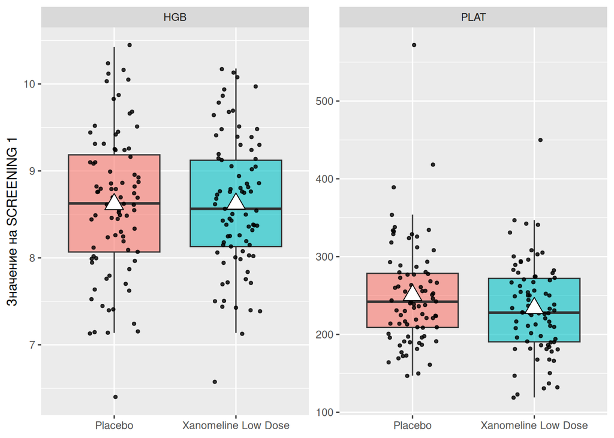

```r
lb_long |>
  filter(!is.na(LBSTRESN)) |>
  ggplot(aes(x = ARM, y = LBSTRESN, fill = ARM)) +
  geom_boxplot(alpha = 0.6, outlier.shape = NA) +
  geom_jitter(width = 0.2, size = 1, alpha = 0.8) +
  facet_wrap(~LBTESTCD, scales = "free_y") +
  stat_summary(
    fun = mean,
    geom = "point",
    shape = 24,
    size = 5,
    fill = "white"
  ) +
  labs(x = NULL, y = "Значение на SCREENING 1") +
  theme(legend.position = "none")
```

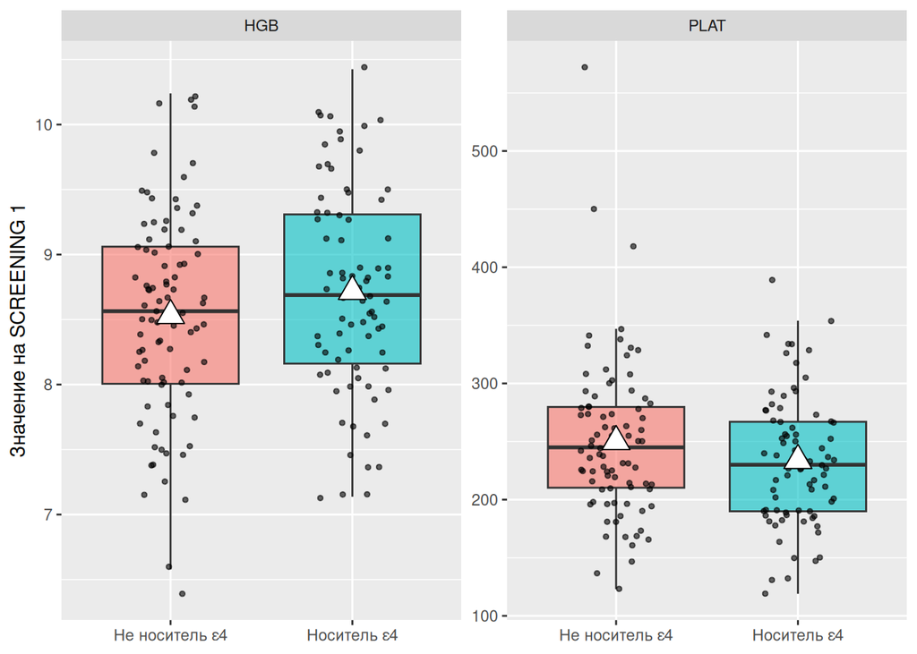

```r
lb_long |>
  filter(!is.na(LBSTRESN)) |>
  ggplot(aes(x = `Носитель ε4`, y = LBSTRESN, fill = `Носитель ε4`)) +
  geom_boxplot(alpha = 0.6, outlier.shape = NA) +
  geom_jitter(width = 0.2, size = 1, alpha = 0.6) +
  facet_wrap(~LBTESTCD, scales = "free_y") +
  stat_summary(
    fun = mean,
    geom = "point",
    shape = 24,
    size = 5,
    fill = "white"
  ) +
  labs(x = NULL, y = "Значение на SCREENING 1") +
  theme(legend.position = "none")
```

**графики для раздела 3.2**

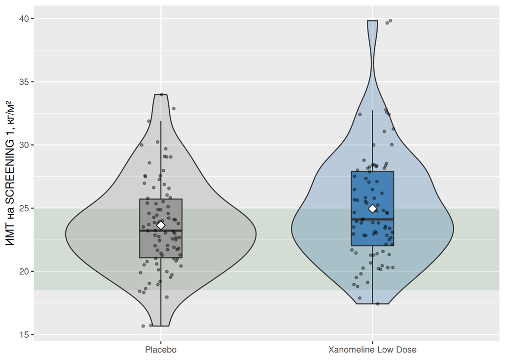

```r
bmi_data |>
  ggplot(aes(x = ARM, y = BMI, fill = ARM)) +
  annotate(
    "rect",
    xmin = -Inf,
    xmax = Inf,
    ymin = 18.5,
    ymax = 25,
    fill = "darkgreen",
    alpha = 0.1
  ) +
  geom_violin(alpha = 0.3) +
  geom_boxplot(width = 0.2, outlier.shape = NA) +
  geom_jitter(width = 0.1, size = 1, alpha = 0.4) +
  stat_summary(
    fun = mean,
    geom = "point",
    shape = 23,
    size = 3,
    fill = "white"
  ) +
  scale_fill_manual(values = arm_colors) +
  labs(x = NULL, y = "ИМТ на SCREENING 1, кг/м²") +
  theme(legend.position = "none")
```

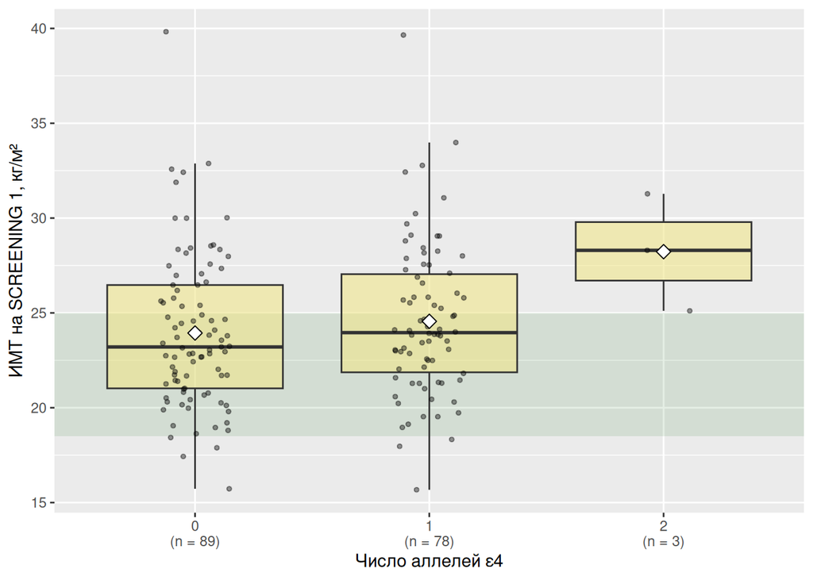

```r
apoe_bmi |>
  group_by(Apoe_num) |>
  mutate(alleles = str_c(Apoe_num, "\n(n = ", n(), ")")) |>
  ungroup() |>
  ggplot(aes(x = alleles, y = BMI)) +
  annotate(
    "rect",
    xmin = -Inf,
    xmax = Inf,
    ymin = 18.5,
    ymax = 25,
    fill = "darkgreen",
    alpha = 0.1
  ) +
  geom_boxplot(outlier.shape = NA, fill = "khaki", alpha = 0.6) +
  geom_jitter(width = 0.15, size = 1, alpha = 0.4) +
  stat_summary(
    fun = mean,
    geom = "point",
    shape = 23,
    size = 3,
    fill = "white"
  ) +
  labs(x = "Число аллелей ε4", y = "ИМТ на SCREENING 1, кг/м²")
```

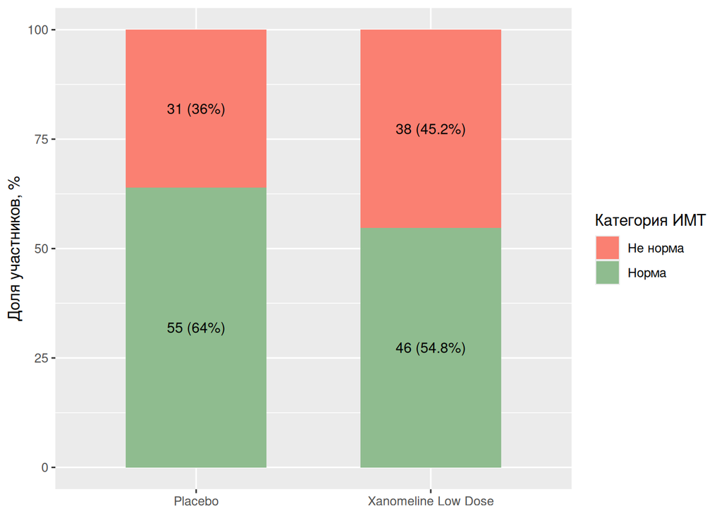

```r
bmi_data |>
  count(ARM, BMI_CATEGORY) |>
  group_by(ARM) |>
  mutate(percent = n / sum(n) * 100) |>
  ungroup() |>
  ggplot(aes(x = ARM, y = percent, fill = BMI_CATEGORY)) +
  geom_col(width = 0.6) +
  geom_text(
    aes(label = str_c(n, " (", round(percent, 1), "%)")),
    position = position_stack(vjust = 0.5),
    size = 3.5
  ) +
  scale_fill_manual(
    values = c("Норма" = "darkseagreen", "Не норма" = "salmon")
  ) +
  labs(x = NULL, y = "Доля участников, %", fill = "Категория ИМТ")
```

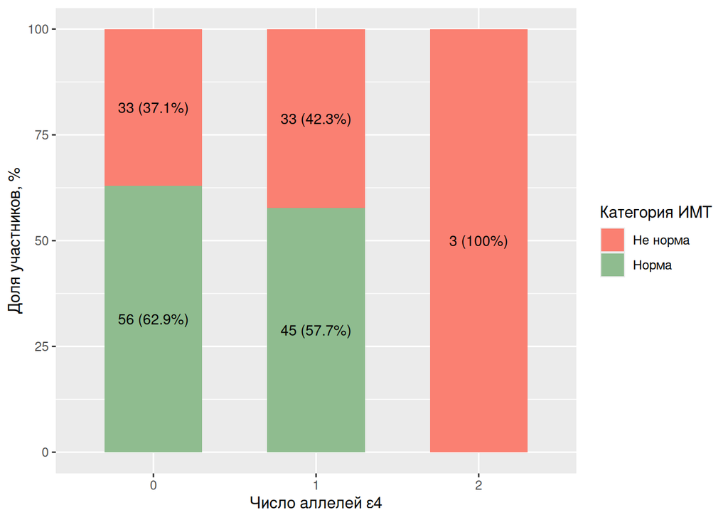

```r
apoe_bmi |>
  count(Apoe_num, BMI_CATEGORY) |>
  group_by(Apoe_num) |>
  mutate(percent = n / sum(n) * 100) |>
  ungroup() |>
  ggplot(aes(x = factor(Apoe_num), y = percent, fill = BMI_CATEGORY)) +
  geom_col(width = 0.6) +
  geom_text(
    aes(label = str_c(n, " (", round(percent, 1), "%)")),
    position = position_stack(vjust = 0.5),
    size = 3.5
  ) +
  scale_fill_manual(
    values = c("Норма" = "darkseagreen", "Не норма" = "salmon")
  ) +
  labs(x = "Число аллелей ε4", y = "Доля участников, %", fill = "Категория ИМТ")
```

**графики для раздела 3.3**

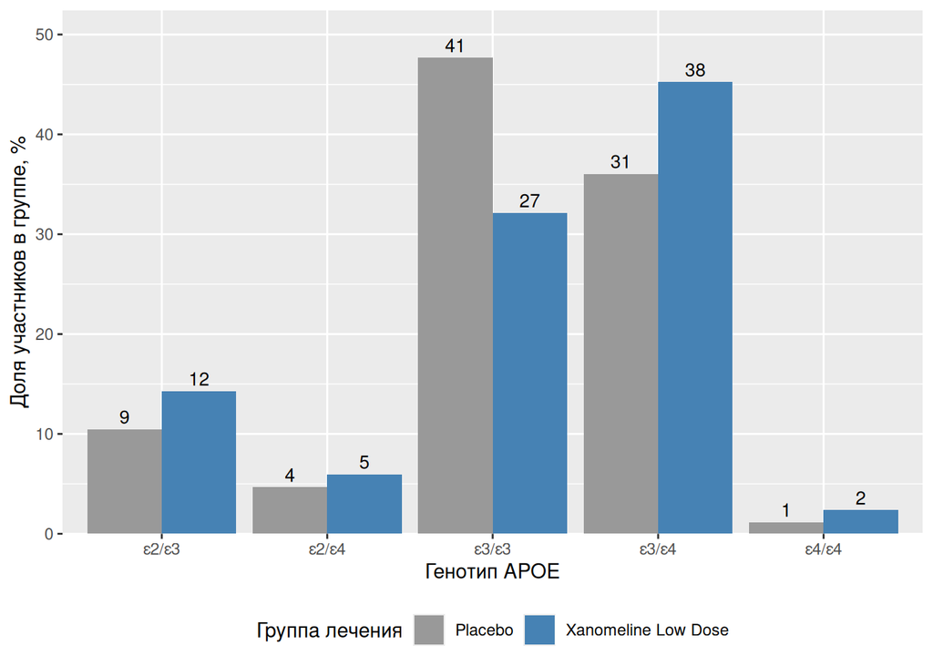

```r
df_filtered |>
  count(ARM, `Генотип APOE`) |>
  group_by(ARM) |>
  mutate(percent = n / sum(n) * 100) |>
  ungroup() |>
  ggplot(aes(x = `Генотип APOE`, y = percent, fill = ARM)) +
  geom_col(position = position_dodge(width = 0.9)) +
  geom_text(
    aes(label = n),
    position = position_dodge(width = 0.9),
    vjust = -0.4,
    size = 3.5
  ) +
  scale_fill_manual(values = arm_colors) +
  scale_y_continuous(expand = expansion(mult = c(0, 0.1))) +
  labs(
    x = "Генотип APOE",
    y = "Доля участников в группе, %",
    fill = "Группа лечения"
  ) +
  theme(legend.position = "bottom")
```

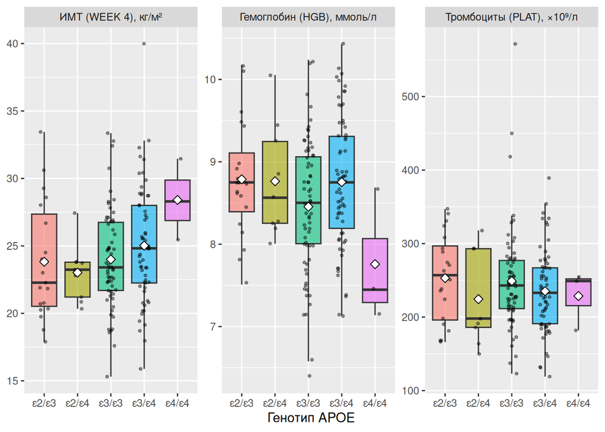

```r
param_labels <- c(
  BMI = "ИМТ (WEEK 4), кг/м²",
  lb_labels
)

stats_long |>
  filter(!is.na(Value)) |>
  ggplot(aes(x = `Генотип APOE`, y = Value, fill = `Генотип APOE`)) +
  geom_boxplot(outlier.shape = NA, alpha = 0.6) +
  geom_jitter(width = 0.15, size = 0.8, alpha = 0.4) +
  stat_summary(
    fun = mean,
    geom = "point",
    shape = 23,
    size = 2.5,
    fill = "white"
  ) +
  facet_wrap(
    ~Parameter,
    scales = "free_y",
    labeller = as_labeller(param_labels)
  ) +
  labs(x = "Генотип APOE", y = NULL) +
  theme(legend.position = "none")
```

### 4.2. Таблицы gtsummary

Воспроизведите значения из таблиц раздела 3 с помощью функции `tbl_summary`, настроив статистики и подписи. Изучите документацию к функции [на сайте](https://www.danieldsjoberg.com/gtsummary/articles/tbl_summary.html).

```r
# См. документацию:
# ?tbl_summary
library(gtsummary) # установка пакетов
```

```r
# превращаем таблицу в широкую, чтобы у показателей HGB и PLAT были в разных колонках
lb_wide_1 <- lb_long |>
  select(ARM, ID, LBTESTCD, LBSTRESN) |>
  pivot_wider(
    names_from = LBTESTCD, # HGB и PLAT(категории анализов) будут в названиях колонок
    values_from = LBSTRESN # численные значения уровней HGB и PLAT
  )
```

```r
# Статистика лабораторных показателей по группам
statistics_arm_lb_quant <- lb_wide_1 |>
  select(ARM, HGB, PLAT) |>
  tbl_summary(
    by = ARM,
    type = all_continuous() ~ "continuous2",
    statistic = all_continuous() ~ c(
      # расчет статистик - по одной строке на параметр
      "{mean} ({sd})",
      "{median} ({p25}, {p75})",
      "{min}, {max}",
      "{N_nonmiss}",
      "{N_miss}"
    ),
    label = list(
      ARM = "Группа лечения",
      HGB = "HGB, ммоль/л",
      PLAT = "PLAT, ×10⁹/л "
    )
  ) |>
  modify_header(label ~ "Показатель")
statistics_arm_lb_quant$table_body <- statistics_arm_lb_quant$table_body |>
  filter(label != "Unknown") # фильтрация чтоб не дублировалась строка "Unknown"
statistics_arm_lb_quant
```

| Показатель | **Placebo** N = 85 | **Xanomeline Low Dose** N = 81 |
| --- | --- | --- |
| HGB, ммоль/л |  |  |
| Mean (SD) | 8.62 (0.83) | 8.62 (0.77) |
| Median (Q1, Q3) | 8.63 (8.07, 9.18) | 8.56 (8.13, 9.12) |
| Min, Max | 6.39, 10.43 | 6.58, 10.18 |
| N Non-missing | 85 | 81 |
| N Missing | 0 | 0 |
| PLAT, ×10⁹/л |  |  |
| Mean (SD) | 250 (66) | 234 (59) |
| Median (Q1, Q3) | 242 (209, 279) | 228 (190, 273) |
| Min, Max | 147, 572 | 119, 450 |
| N Non-missing | 84 | 79 |
| N Missing | 1 | 2 |

```r
# создаем широкую таблицу, чтобы показатели HGB и PLAT были в разных колонках (и статистики были подсчитаны отдельно для каждой группы анализов)
lb_wide_2 <- lb_long |>
  select(ARM, ID, LBTESTCD, LBSTRESN, `Носитель ε4`) |>
  pivot_wider(
    names_from = LBTESTCD,
    values_from = LBSTRESN
  )
```

```r
# Статистика лабораторных показателей по носителям
# Подсчет статистик с функцией tbl_summary()
statistics_arm_lb_cat <- lb_wide_2 |>
  select(`Носитель ε4`, HGB, PLAT) |>
  #
  tbl_summary(
    by = `Носитель ε4`,
    type = all_continuous() ~ "continuous2",
    statistic = all_continuous() ~ c(
      "{mean} ({sd})",
      "{median} ({p25}, {p75})",
      "{min}, {max}",
      "{N_nonmiss}",
      "{N_miss}"
    ),
    label = list(
      ARM = "Носитель ε4",
      HGB = "HGB, ммоль/л",
      PLAT = "PLAT, ×10⁹/л "
    )
  ) |>
  modify_header(label ~ "Показатель")
statistics_arm_lb_cat$table_body <- statistics_arm_lb_cat$table_body |>
  filter(label != "Unknown") # фильтрация чтоб не дублировалась строка "Unknown"
statistics_arm_lb_cat
```

| Показатель | **Не носитель ε4** N = 87 | **Носитель ε4** N = 79 |
| --- | --- | --- |
| HGB, ммоль/л |  |  |
| Mean (SD) | 8.53 (0.80) | 8.72 (0.79) |
| Median (Q1, Q3) | 8.56 (8.01, 9.06) | 8.69 (8.13, 9.31) |
| Min, Max | 6.39, 10.24 | 7.14, 10.43 |
| N Non-missing | 87 | 79 |
| N Missing | 0 | 0 |
| PLAT, ×10⁹/л |  |  |
| Mean (SD) | 250 (67) | 234 (56) |
| Median (Q1, Q3) | 245 (210, 280) | 230 (190, 267) |
| Min, Max | 123, 572 | 119, 389 |
| N Non-missing | 86 | 77 |
| N Missing | 1 | 2 |

```r
# статистика по количественным показателям по группам (с помощью функции tbl_summary())
statistic_ARM_vs_quant <- bmi_data |>
  select(ARM, BMI) |>
  tbl_summary(
    by = ARM,
    type = all_continuous() ~ "continuous2",
    statistic = all_continuous() ~ c(
      "{mean} ({sd})",
      "{median} ({p25}, {p75})",
      "{min}, {max}",
      "{N_nonmiss}",
      "{N_miss}"
    ),
    label = list(
      ARM = "Группа лечения",
      BMI = "ИМТ на скрининге"
    )
  ) |>
  modify_header(label ~ "Показатель")
statistic_ARM_vs_quant
```

| Показатель | **Placebo** N = 86 | **Xanomeline Low Dose** N = 84 |
| --- | --- | --- |
| ИМТ на скрининге |  |  |
| Mean (SD) | 23.6 (3.6) | 25.0 (4.3) |
| Median (Q1, Q3) | 23.2 (21.0, 25.8) | 24.1 (21.9, 27.9) |
| Min, Max | 15.7, 34.0 | 17.4, 39.8 |
| N Non-missing | 86 | 84 |
| N Missing | 0 | 0 |

```r
# категория норма/не норма по группам
statistic_ARM_vs_cat <- bmi_data |>
  select(ARM, BMI_CATEGORY) |>
  tbl_summary(
    by = ARM,
    statistic = all_categorical() ~ "{n} ({p}%)",
    percent = "column",
    label = list(
      ARM = "Группа лечения",
      BMI_CATEGORY = "Категория ИМТ"
    )
  ) |>
  modify_header(label ~ "Показатель")
statistic_ARM_vs_cat
```

| Показатель | **Placebo** N = 86<sup>1</sup> | **Xanomeline Low Dose** N = 84<sup>1</sup> |
| --- | --- | --- |
| Категория ИМТ |  |  |
| Не норма | 31 (36%) | 38 (45%) |
| Норма | 55 (64%) | 46 (55%) |

<sup>1</sup> n (%)

```r
# количественная статистика по APOE
statistic_APOE_vs_quant <- apoe_bmi |>
  select(Apoe_num, BMI) |>
  tbl_summary(
    by = Apoe_num,
    type = all_continuous() ~ "continuous2",
    statistic = all_continuous() ~ c(
      "{mean} ({sd})",
      "{median} ({p25}, {p75})",
      "{min}, {max}",
      "{N_nonmiss}",
      "{N_miss}"
    ),
    label = list(
      Apoe_num = "Число аллелей ε4",
      BMI = "ИМТ на скрининге"
    )
  ) |>
  modify_header(label ~ "Показатель")
statistic_APOE_vs_quant
```

| Показатель | **0** N = 89 | **1** N = 78 | **2** N = 3 |
| --- | --- | --- | --- |
| ИМТ на скрининге |  |  |  |
| Mean (SD) | 23.9 (4.0) | 24.6 (4.0) | 28.2 (3.1) |
| Median (Q1, Q3) | 23.2 (21.0, 26.5) | 24.0 (21.8, 27.1) | 28.3 (25.1, 31.3) |
| Min, Max | 15.7, 39.8 | 15.7, 39.7 | 25.1, 31.3 |
| N Non-missing | 89 | 78 | 3 |
| N Missing | 0 | 0 | 0 |

```r
# по категориям норма/не норма по APOE
statistic_APOE_vs_cat <- apoe_bmi |>
  select(Apoe_num, BMI_CATEGORY) |>
  tbl_summary(
    by = Apoe_num,
    statistic = all_categorical() ~ "{n} ({p}%)",
    percent = "column",
    label = list(
      Apoe_num = "Число аллелей ε4",
      BMI_CATEGORY = "Категория ИМТ"
    )
  ) |>
  modify_header(label ~ "Показатель")
statistic_APOE_vs_cat
```

| Показатель | **0** N = 89<sup>1</sup> | **1** N = 78<sup>1</sup> | **2** N = 3<sup>1</sup> |
| --- | --- | --- | --- |
| Категория ИМТ |  |  |  |
| Не норма | 33 (37%) | 33 (42%) | 3 (100%) |
| Норма | 56 (63%) | 45 (58%) | 0 (0%) |

<sup>1</sup> n (%)

```r
# Число и процент участников с каждым генотипом APOE по группам лечения
apoe_category_stat <- df_filtered |>
  select(ARM, `Генотип APOE`) |>
  tbl_summary(
    by = ARM,
    statistic = all_categorical() ~ "{n} ({p}%)",
    percent = "column",
    label = list(
      ARM = "Группа лечения",
      `Генотип APOE` = "Генотип APOE"
    )
  ) |>
  modify_header(label ~ "Показатель")
apoe_category_stat
```

| Показатель | **Placebo** N = 86<sup>1</sup> | **Xanomeline Low Dose** N = 84<sup>1</sup> |
| --- | --- | --- |
| Генотип APOE |  |  |
| ε2/ε3 | 9 (10%) | 12 (14%) |
| ε2/ε4 | 4 (4.7%) | 5 (6.0%) |
| ε3/ε3 | 41 (48%) | 27 (32%) |
| ε3/ε4 | 31 (36%) | 38 (45%) |
| ε4/ε4 | 1 (1.2%) | 2 (2.4%) |

<sup>1</sup> n (%)

```r
# Статистики BMI и лабораторных показателей в зависимости от генотипа APOE
apoe_quant_stat <- df_filtered |>
  select(`Генотип APOE`, BMI, PLAT, HGB) |>
  tbl_summary(
    by = `Генотип APOE`,
    type = all_continuous() ~ "continuous2",
    statistic = all_continuous() ~ c(
      "{mean} ({sd})",
      "{median} ({p25}, {p75})",
      "{min}, {max}",
      "{N_nonmiss}",
      "{N_miss}"
    ),
    label = list(
      `Генотип APOE` = "Генотип APOE",
      BMI = "ИМТ (BMI), кг/м² (WEEK 4)",
      HGB = "HGB (Гемоглобин), ммоль/л",
      PLAT = "PLAT (Тромбоциты), ×10⁹/л"
    )
  ) |>
  modify_header(label ~ "Показатель")
apoe_quant_stat$table_body <- apoe_quant_stat$table_body |>
  filter(label != "Unknown") # фильтрация чтоб не дублировалась строка "Unknown"
apoe_quant_stat
```

| Показатель | **ε2/ε3** N = 21 | **ε2/ε4** N = 9 | **ε3/ε3** N = 68 | **ε3/ε4** N = 69 | **ε4/ε4** N = 3 |
| --- | --- | --- | --- | --- | --- |
| ИМТ (BMI), кг/м² (WEEK 4) |  |  |  |  |  |
| Mean (SD) | 23.8 (4.4) | 23.0 (2.1) | 24.0 (3.7) | 25.0 (4.3) | 28.4 (3.0) |
| Median (Q1, Q3) | 22.3 (20.3, 28.0) | 23.2 (21.2, 23.8) | 23.4 (21.7, 26.8) | 24.8 (22.2, 28.0) | 28.3 (25.5, 31.5) |
| Min, Max | 17.9, 33.4 | 20.3, 27.4 | 15.3, 33.4 | 15.9, 40.0 | 25.5, 31.5 |
| N Non-missing | 19 | 9 | 62 | 61 | 3 |
| N Missing | 2 | 0 | 6 | 8 | 0 |
| PLAT (Тромбоциты), ×10⁹/л |  |  |  |  |  |
| Mean (SD) | 253 (61) | 224 (62) | 249 (70) | 235 (56) | 229 (41) |
| Median (Q1, Q3) | 257 (194, 301) | 198 (186, 293) | 243 (211, 278) | 233 (191, 267) | 249 (182, 255) |
| Min, Max | 166, 347 | 150, 318 | 123, 572 | 119, 389 | 182, 255 |
| N Non-missing | 20 | 9 | 66 | 65 | 3 |
| N Missing | 1 | 0 | 2 | 4 | 0 |
| HGB (Гемоглобин), ммоль/л |  |  |  |  |  |
| Mean (SD) | 8.79 (0.71) | 8.76 (0.69) | 8.45 (0.81) | 8.75 (0.79) | 7.76 (0.82) |
| Median (Q1, Q3) | 8.75 (8.35, 9.22) | 8.56 (8.25, 9.25) | 8.50 (8.01, 9.06) | 8.75 (8.13, 9.31) | 7.45 (7.14, 8.69) |
| Min, Max | 7.51, 10.18 | 8.01, 10.05 | 6.39, 10.24 | 7.14, 10.43 | 7.14, 8.69 |
| N Non-missing | 20 | 9 | 67 | 67 | 3 |
| N Missing | 1 | 0 | 1 | 2 | 0 |

### 4.3. Заполнение пропущенных значений

Создайте и загрузите на GitHub экспериментальную ветку `imputation`. В этой ветке перед разделом 3 заполните пропущенные значения количественных показателей, используемых в анализе, средним значением показателя в группе по полу и возрасту. Используйте возрастные группы 50-59, 60-69, 70-79 и 80-89 лет. В дальнейшем анализе используйте датафрейм после заполнения пропусков.